# Technical Challenge: HCC Survival Dataset

### Model selection via automated model selection and model-averaging

Selected the top 12 predictors as per random forest for `glmulti`

```r
modelClinical.glmulti <- glmulti(lives ~ creatinine + hepBcAb + protein_total + leuk +
                                     diabetes + obesity + mcv + symptoms +
                                     hypertension + alcohol + hemochromatosis + renalInsufficiency,
                             data = dataClinical,
                             level = 1,
                             crit = "bic",
                             confsetsize = 1,
                             fitfunction = "glm",
                             family = binomial)
```

```
## Initialization...
## TASK: Exhaustive screening of candidate set.
## Fitting...
##
## After 50 models:
## Best model: lives~1
## Crit= 180.006419916201
## Mean crit= 180.006419916201
```

```
##
## After 100 models:
## Best model: lives~1
## Crit= 180.006419916201
## Mean crit= 180.006419916201
```

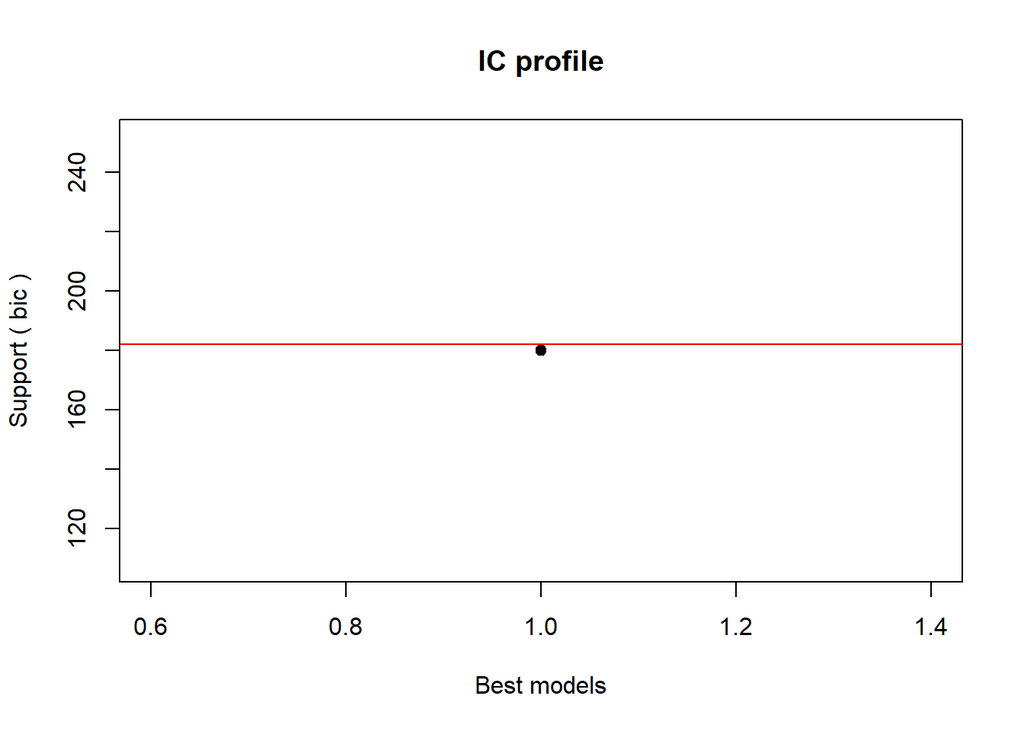

```
##
## After 150 models:
## Best model: lives~1+symptoms
## Crit= 177.784036934238
## Mean crit= 177.784036934238
```

```
##
## After 200 models:
## Best model: lives~1+symptoms
## Crit= 177.784036934238
## Mean crit= 177.784036934238
```

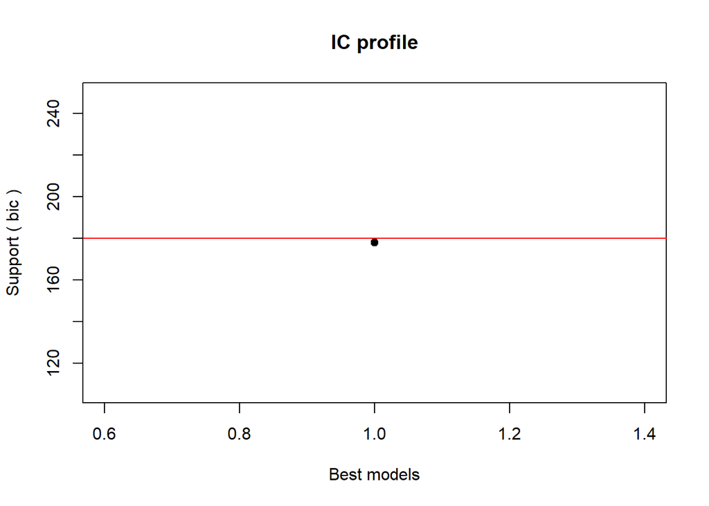

```
##
## After 250 models:
## Best model: lives~1+symptoms
## Crit= 177.784036934238
## Mean crit= 177.784036934238
```

```
##
## After 300 models:
## Best model: lives~1+symptoms
## Crit= 177.784036934238
## Mean crit= 177.784036934238
```

```
##
## After 350 models:
## Best model: lives~1+symptoms
## Crit= 177.784036934238
## Mean crit= 177.784036934238
```

```
##
## After 400 models:
## Best model: lives~1+symptoms
## Crit= 177.784036934238
## Mean crit= 177.784036934238
```

```
##
## After 450 models:
## Best model: lives~1+diabetes+symptoms+hypertension+creatinine
## Crit= 173.975183598306
## Mean crit= 173.975183598306
```

```
##
## After 500 models:
## Best model: lives~1+diabetes+symptoms+hypertension+creatinine
## Crit= 173.975183598306
## Mean crit= 173.975183598306
```

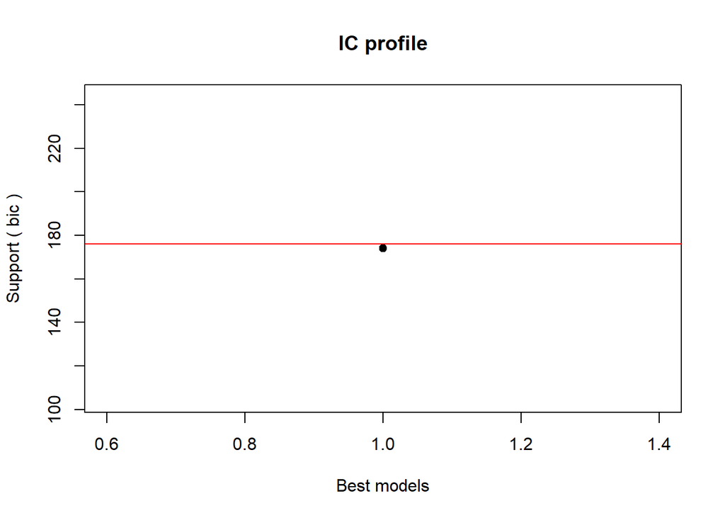

```
##
## After 550 models:
## Best model: lives~1+diabetes+symptoms+hypertension+creatinine
## Crit= 173.975183598306
## Mean crit= 173.975183598306
```

```
##
## After 600 models:
## Best model: lives~1+diabetes+symptoms+hypertension+creatinine
## Crit= 173.975183598306
## Mean crit= 173.975183598306
```

```
##
## After 650 models:
## Best model: lives~1+diabetes+symptoms+hypertension+creatinine
## Crit= 173.975183598306
## Mean crit= 173.975183598306
```

```
##
## After 700 models:
## Best model: lives~1+diabetes+symptoms+hypertension+creatinine
## Crit= 173.975183598306
## Mean crit= 173.975183598306
```

```
##
## After 750 models:
## Best model: lives~1+diabetes+symptoms+hypertension+creatinine
## Crit= 173.975183598306
## Mean crit= 173.975183598306
```

```
##
## After 800 models:
## Best model: lives~1+diabetes+symptoms+hypertension+creatinine
## Crit= 173.975183598306
## Mean crit= 173.975183598306
```

```
##
## After 850 models:
## Best model: lives~1+diabetes+symptoms+hypertension+creatinine
## Crit= 173.975183598306
## Mean crit= 173.975183598306
```

```
##
## After 900 models:
## Best model: lives~1+diabetes+symptoms+hypertension+creatinine
## Crit= 173.975183598306
## Mean crit= 173.975183598306
```

```
##
## After 950 models:
## Best model: lives~1+diabetes+symptoms+hypertension+creatinine
## Crit= 173.975183598306
## Mean crit= 173.975183598306
```

```
##
## After 1000 models:
## Best model: lives~1+diabetes+symptoms+hypertension+creatinine
## Crit= 173.975183598306
## Mean crit= 173.975183598306
```

```
##
## After 1050 models:
## Best model: lives~1+diabetes+symptoms+hypertension+creatinine
## Crit= 173.975183598306
## Mean crit= 173.975183598306
```

```
##
## After 1100 models:
## Best model: lives~1+diabetes+symptoms+hypertension+creatinine
## Crit= 173.975183598306
## Mean crit= 173.975183598306
```

```
##
## After 1150 models:
## Best model: lives~1+diabetes+symptoms+hypertension+creatinine
## Crit= 173.975183598306
## Mean crit= 173.975183598306
```

```
##
## After 1200 models:
## Best model: lives~1+diabetes+symptoms+hypertension+creatinine
## Crit= 173.975183598306
## Mean crit= 173.975183598306
```

```
##
## After 1250 models:
## Best model: lives~1+diabetes+symptoms+hypertension+creatinine
## Crit= 173.975183598306
## Mean crit= 173.975183598306
```

```
##
## After 1300 models:
## Best model: lives~1+diabetes+symptoms+hypertension+creatinine
## Crit= 173.975183598306
## Mean crit= 173.975183598306
```

```
##
## After 1350 models:
## Best model: lives~1+diabetes+symptoms+hypertension+creatinine
## Crit= 173.975183598306
## Mean crit= 173.975183598306
```

```
##
## After 1400 models:
## Best model: lives~1+diabetes+symptoms+hypertension+creatinine
## Crit= 173.975183598306
## Mean crit= 173.975183598306
```

```
##
## After 1450 models:
## Best model: lives~1+diabetes+symptoms+hypertension+creatinine
## Crit= 173.975183598306
## Mean crit= 173.975183598306
```

```
##
## After 1500 models:
## Best model: lives~1+diabetes+symptoms+hypertension+creatinine
## Crit= 173.975183598306
## Mean crit= 173.975183598306
```

```
##
## After 1550 models:
## Best model: lives~1+diabetes+symptoms+hypertension+creatinine
## Crit= 173.975183598306
## Mean crit= 173.975183598306
```

```
##
## After 1600 models:
## Best model: lives~1+diabetes+symptoms+hypertension+creatinine
## Crit= 173.975183598306
## Mean crit= 173.975183598306
```

```
##
## After 1650 models:
## Best model: lives~1+diabetes+symptoms+hypertension+creatinine
## Crit= 173.975183598306
## Mean crit= 173.975183598306
```

```
##
## After 1700 models:
## Best model: lives~1+diabetes+symptoms+hypertension+creatinine
## Crit= 173.975183598306
## Mean crit= 173.975183598306
```

```
##
## After 1750 models:
## Best model: lives~1+diabetes+symptoms+hypertension+creatinine
## Crit= 173.975183598306
## Mean crit= 173.975183598306
```

```
##
## After 1800 models:
## Best model: lives~1+diabetes+symptoms+hypertension+creatinine
## Crit= 173.975183598306
## Mean crit= 173.975183598306
```

```
##
## After 1850 models:
## Best model: lives~1+diabetes+symptoms+hypertension+creatinine
## Crit= 173.975183598306
## Mean crit= 173.975183598306
```

```
##
## After 1900 models:
## Best model: lives~1+diabetes+symptoms+hypertension+creatinine
## Crit= 173.975183598306
## Mean crit= 173.975183598306
```

```
##
## After 1950 models:
## Best model: lives~1+diabetes+symptoms+hypertension+creatinine
## Crit= 173.975183598306
## Mean crit= 173.975183598306
```

```
##
## After 2000 models:
## Best model: lives~1+diabetes+symptoms+hypertension+creatinine
## Crit= 173.975183598306
## Mean crit= 173.975183598306
```

```
##
## After 2050 models:
## Best model: lives~1+diabetes+symptoms+hypertension+creatinine
## Crit= 173.975183598306
## Mean crit= 173.975183598306
```

```
##
## After 2100 models:
## Best model: lives~1+diabetes+symptoms+hypertension+creatinine
## Crit= 173.975183598306
## Mean crit= 173.975183598306
```

```
##
## After 2150 models:
## Best model: lives~1+diabetes+symptoms+hypertension+creatinine
## Crit= 173.975183598306
## Mean crit= 173.975183598306
```

```
##
## After 2200 models:
## Best model: lives~1+diabetes+symptoms+hypertension+creatinine
## Crit= 173.975183598306
## Mean crit= 173.975183598306
```

```
##
## After 2250 models:
## Best model: lives~1+diabetes+symptoms+hypertension+creatinine
## Crit= 173.975183598306
## Mean crit= 173.975183598306
```

```
##
## After 2300 models:
## Best model: lives~1+diabetes+symptoms+hypertension+creatinine
## Crit= 173.975183598306
## Mean crit= 173.975183598306
```

```
##
## After 2350 models:
## Best model: lives~1+diabetes+symptoms+hypertension+creatinine
## Crit= 173.975183598306
## Mean crit= 173.975183598306
```

```
##
## After 2400 models:
## Best model: lives~1+diabetes+symptoms+hypertension+creatinine
## Crit= 173.975183598306
## Mean crit= 173.975183598306
```

```
##
## After 2450 models:
## Best model: lives~1+diabetes+symptoms+hypertension+creatinine
## Crit= 173.975183598306
## Mean crit= 173.975183598306
```

```
##
## After 2500 models:
## Best model: lives~1+diabetes+symptoms+hypertension+creatinine
## Crit= 173.975183598306
## Mean crit= 173.975183598306
```

```
##
## After 2550 models:
## Best model: lives~1+diabetes+symptoms+hypertension+creatinine
## Crit= 173.975183598306
## Mean crit= 173.975183598306
```

```
##
## After 2600 models:
## Best model: lives~1+diabetes+symptoms+hypertension+creatinine
## Crit= 173.975183598306
## Mean crit= 173.975183598306
```

```
##
## After 2650 models:
## Best model: lives~1+diabetes+symptoms+hypertension+creatinine
## Crit= 173.975183598306
## Mean crit= 173.975183598306
```

```
##
## After 2700 models:
## Best model: lives~1+diabetes+symptoms+hypertension+creatinine
## Crit= 173.975183598306
## Mean crit= 173.975183598306
```

```
##
## After 2750 models:
## Best model: lives~1+diabetes+symptoms+hypertension+creatinine
## Crit= 173.975183598306
## Mean crit= 173.975183598306
```

```
##
## After 2800 models:
## Best model: lives~1+diabetes+symptoms+hypertension+creatinine
## Crit= 173.975183598306
## Mean crit= 173.975183598306
```

```
##
## After 2850 models:
## Best model: lives~1+diabetes+symptoms+hypertension+creatinine
## Crit= 173.975183598306
## Mean crit= 173.975183598306
```

```
##
## After 2900 models:
## Best model: lives~1+diabetes+symptoms+hypertension+creatinine
## Crit= 173.975183598306
## Mean crit= 173.975183598306
```

```
##
## After 2950 models:
## Best model: lives~1+diabetes+symptoms+hypertension+creatinine
## Crit= 173.975183598306
## Mean crit= 173.975183598306
```

```
##
## After 3000 models:
## Best model: lives~1+diabetes+symptoms+hypertension+creatinine
## Crit= 173.975183598306
## Mean crit= 173.975183598306
```

```
##
## After 3050 models:
## Best model: lives~1+diabetes+symptoms+hypertension+creatinine
## Crit= 173.975183598306
## Mean crit= 173.975183598306
```

```
##
## After 3100 models:
## Best model: lives~1+diabetes+symptoms+hypertension+creatinine
## Crit= 173.975183598306
## Mean crit= 173.975183598306
```

```
##
## After 3150 models:
## Best model: lives~1+diabetes+symptoms+hypertension+creatinine
## Crit= 173.975183598306
## Mean crit= 173.975183598306
```

```
##
## After 3200 models:
## Best model: lives~1+diabetes+symptoms+hypertension+creatinine
## Crit= 173.975183598306
## Mean crit= 173.975183598306
```

```
##
## After 3250 models:
## Best model: lives~1+diabetes+symptoms+hypertension+creatinine
## Crit= 173.975183598306
## Mean crit= 173.975183598306
```

```
##
## After 3300 models:
## Best model: lives~1+diabetes+symptoms+hypertension+creatinine
## Crit= 173.975183598306
## Mean crit= 173.975183598306
```

```
##
## After 3350 models:
## Best model: lives~1+diabetes+symptoms+hypertension+creatinine
## Crit= 173.975183598306
## Mean crit= 173.975183598306
```

```
##
## After 3400 models:
## Best model: lives~1+diabetes+symptoms+hypertension+creatinine
## Crit= 173.975183598306
## Mean crit= 173.975183598306
```

```
##
## After 3450 models:
## Best model: lives~1+diabetes+symptoms+hypertension+creatinine
## Crit= 173.975183598306
## Mean crit= 173.975183598306
```

```
##
## After 3500 models:
## Best model: lives~1+diabetes+symptoms+hypertension+creatinine
## Crit= 173.975183598306
## Mean crit= 173.975183598306
```

```
##
## After 3550 models:
## Best model: lives~1+diabetes+symptoms+hypertension+creatinine
## Crit= 173.975183598306
## Mean crit= 173.975183598306
```

```
##
## After 3600 models:
## Best model: lives~1+diabetes+symptoms+hypertension+creatinine
## Crit= 173.975183598306
## Mean crit= 173.975183598306
```

```
##
## After 3650 models:
## Best model: lives~1+diabetes+symptoms+hypertension+creatinine
## Crit= 173.975183598306
## Mean crit= 173.975183598306
```

```
##
## After 3700 models:
## Best model: lives~1+diabetes+symptoms+hypertension+creatinine
## Crit= 173.975183598306
## Mean crit= 173.975183598306
```

```
##
## After 3750 models:
## Best model: lives~1+diabetes+symptoms+hypertension+creatinine
## Crit= 173.975183598306
## Mean crit= 173.975183598306
```

```
##
## After 3800 models:
## Best model: lives~1+diabetes+symptoms+hypertension+creatinine
## Crit= 173.975183598306
## Mean crit= 173.975183598306
```

```
##
## After 3850 models:
## Best model: lives~1+diabetes+symptoms+hypertension+creatinine
## Crit= 173.975183598306
## Mean crit= 173.975183598306
```

```
##
## After 3900 models:
## Best model: lives~1+diabetes+symptoms+hypertension+creatinine
## Crit= 173.975183598306
## Mean crit= 173.975183598306
```

```
##
## After 3950 models:
## Best model: lives~1+diabetes+symptoms+hypertension+creatinine
## Crit= 173.975183598306
## Mean crit= 173.975183598306
```

```
##
## After 4000 models:
## Best model: lives~1+diabetes+symptoms+hypertension+creatinine
## Crit= 173.975183598306
## Mean crit= 173.975183598306
```

```
##
## After 4050 models:
## Best model: lives~1+diabetes+symptoms+hypertension+creatinine
## Crit= 173.975183598306
## Mean crit= 173.975183598306
```

```
##
## After 4100 models:
## Best model: lives~1+diabetes+symptoms+hypertension+creatinine
## Crit= 173.975183598306
## Mean crit= 173.975183598306
```

```
##
## After 4150 models:
## Best model: lives~1+diabetes+symptoms+hypertension+creatinine
## Crit= 173.975183598306
## Mean crit= 173.975183598306
```

```
##
## After 4200 models:
## Best model: lives~1+diabetes+symptoms+hypertension+creatinine
## Crit= 173.975183598306
## Mean crit= 173.975183598306
```

```
##
## After 4250 models:
## Best model: lives~1+diabetes+symptoms+hypertension+creatinine
## Crit= 173.975183598306
## Mean crit= 173.975183598306
```

```
## Completed.
```

```r
print(modelClinical.glmulti)
```

```
## glmulti.analysis
## Method: h / Fitting: glm / IC used: bic
## Level: 1 / Marginality: FALSE
## From 1 models:
## Best IC: 173.975183598306
## Best model:
## [1] "lives ~ 1 + diabetes + symptoms + hypertension + creatinine"
## Evidence weight: 1
## Worst IC: 173.975183598306
## 1 models within 2 IC units.
## 0 models to reach 95% of evidence weight.
```

```r
modelClinicalC <- glm(lives ~ diabetes + symptoms + hypertension + creatinine,
                      dataClinical,
                      family = "binomial")

summary(modelClinicalC)
```

```
##
## Call:
## glm(formula = lives ~ diabetes + symptoms + hypertension + creatinine,
##     family = "binomial", data = dataClinical)
##
## Deviance Residuals:
##     Min       1Q   Median       3Q      Max
## -1.8990  -1.1481   0.5978   1.0868   1.8244
##
## Coefficients:
##               Estimate Std. Error z value Pr(>|z|)
## (Intercept)     1.9570     0.4945   3.958 7.57e-05 ***
## diabetes1      -1.4981     0.4834  -3.099  0.00194 **
## symptoms1      -1.5071     0.4576  -3.293  0.00099 ***
## hypertension1   1.5290     0.4990   3.064  0.00218 **
## creatinine     -0.4513     0.2060  -2.191  0.02848 *
## ---
## Signif. codes:  0 '***' 0.001 '**' 0.01 '*' 0.05 '.' 0.1 ' ' 1
##
## (Dispersion parameter for binomial family taken to be 1)
##
##     Null deviance: 175.13  on 130  degrees of freedom
## Residual deviance: 149.60  on 126  degrees of freedom
## AIC: 159.6
##
## Number of Fisher Scoring iterations: 4
```

### Model error check

```r
# Multicollinearity
vif(modelClinicalA)
```

```
##          age     diabetes hypertension     symptoms   creatinine
##     1.161709     1.370301     1.642944     1.157584     1.115903
##         leuk
##     1.073787
```

```r
vif(modelClinicalB)
```

```
##          age     diabetes hypertension     symptoms
##     1.146972     1.357498     1.555617     1.157113
```

```r
vif(modelClinicalC)
```

```
##     diabetes     symptoms hypertension   creatinine
##     1.398315     1.126072     1.479296     1.091409
```

```r
# Autocorrelation
durbinWatsonTest(modelClinicalA)
```

```
##  lag Autocorrelation D-W Statistic p-value
##    1     -0.08422387      2.152277    0.36
##  Alternative hypothesis: rho != 0
```

```r
durbinWatsonTest(modelClinicalB)
```

```
##  lag Autocorrelation D-W Statistic p-value
##    1     -0.09602994      2.172458   0.284
##  Alternative hypothesis: rho != 0
```

```r
durbinWatsonTest(modelClinicalC)
```

```
##  lag Autocorrelation D-W Statistic p-value
##    1      -0.1241954      2.236129   0.184
##  Alternative hypothesis: rho != 0
```

```r
# Check goodness of fit with Hosmer lemeshow
gof(modelClinicalA, plotROC = FALSE)$gof[1]
```

```
##    test  stat      val df      pVal
## 1:   HL chiSq 3.972442  8 0.8596012
```

```r
gof(modelClinicalB, plotROC = FALSE)$gof[1]
```

```
##    test  stat      val df      pVal
## 1:   HL chiSq 9.849115  8 0.2757763
```

```r
gof(modelClinicalC, plotROC = FALSE)$gof[1]
```

```
##    test  stat      val df      pVal
## 1:   HL chiSq 8.844076  8 0.3556199
```

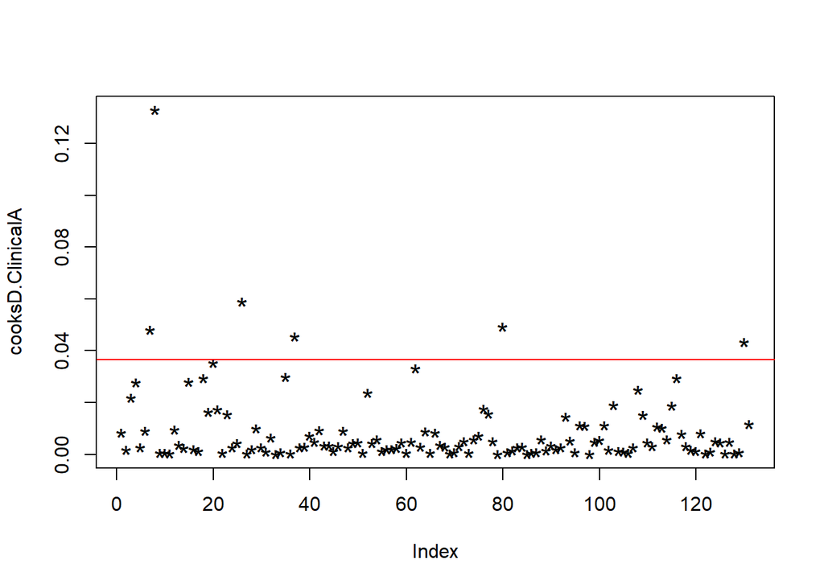

```r
# Review influential observations with Cook's Distance
cooksD.ClinicalA <- cooks.distance(modelClinicalA)
plot(cooksD.ClinicalA, pch = "*", cex = 1.5)
abline(h = 4*mean(cooksD.ClinicalA, na.rm = TRUE), col = "red")
```

```r
influentialRows.ClinicalA <- which(cooksD.ClinicalA > 4*mean(cooksD.ClinicalA, na.rm = TRUE))
dataClinical %>%  # print influential observations
    dplyr::select(one_of(names(modelClinicalA$model)[-1])) %>%
    slice(influentialRows.ClinicalA)
```

```
##   age diabetes hypertension symptoms creatinine    leuk
## 1  41        0            0        0       0.80     5.7
## 2  74        0            1        0       7.60     4.0
## 3  77        0            1        1       1.72 13000.0
## 4  60        1            0        0       0.72  8300.0
## 5  93        0            0        1       2.19     7.9
## 6  44        0            0        0       0.74  5200.0
```

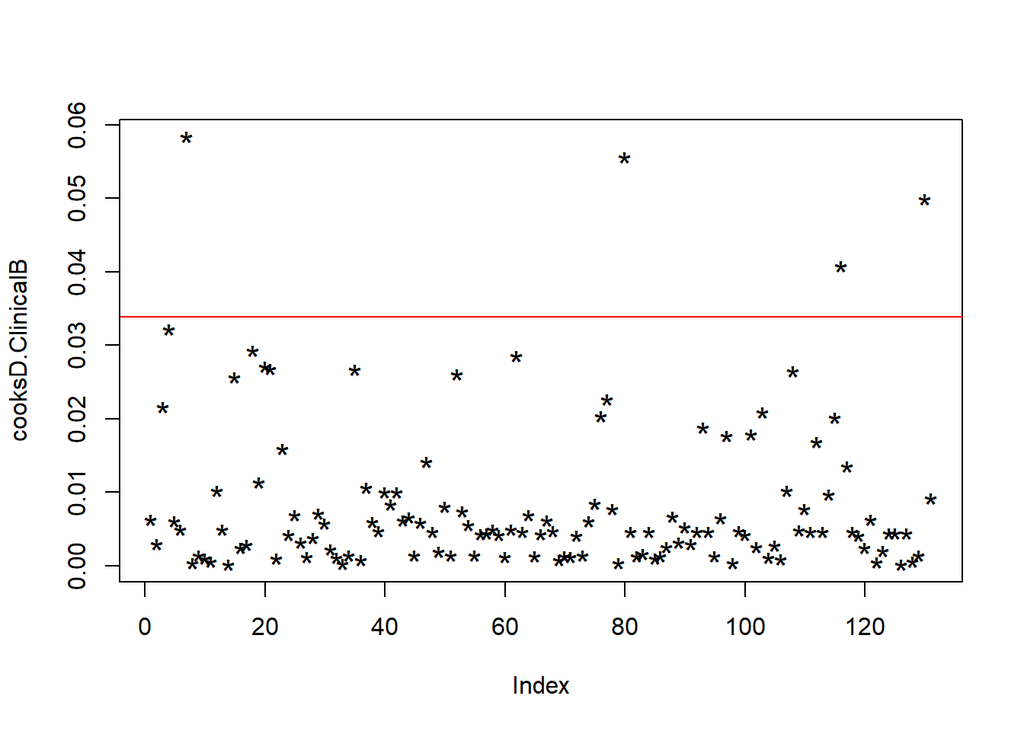

```r
cooksD.ClinicalB <- cooks.distance(modelClinicalB)
plot(cooksD.ClinicalB, pch = "*", cex = 1.5)
abline(h = 4*mean(cooksD.ClinicalB, na.rm = TRUE), col = "red")
```

```r
influentialRows.ClinicalB <- which(cooksD.ClinicalB > 4*mean(cooksD.ClinicalB, na.rm = TRUE))
dataClinical %>%  # print influential observations
    dplyr::select(one_of(names(modelClinicalB$model)[-1])) %>%
    slice(influentialRows.ClinicalB)
```

```
##   age diabetes hypertension symptoms
## 1  41        0            0        0
## 2  93        0            0        1
## 3  67        1            0        1
## 4  44        0            0        0
```

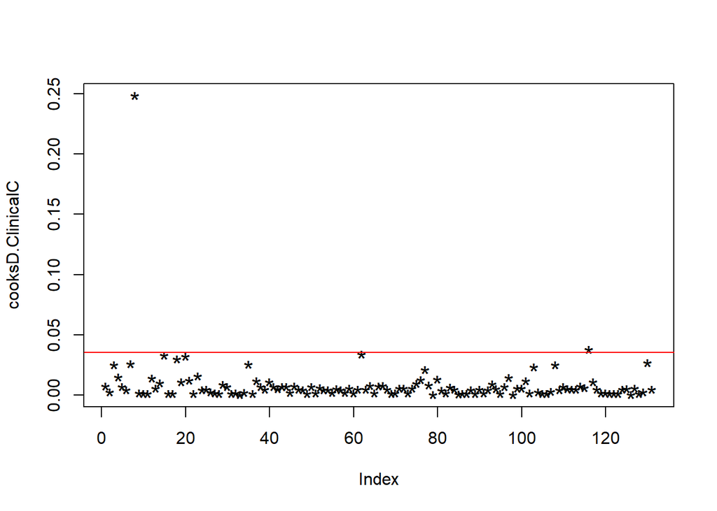

```r
cooksD.ClinicalC <- cooks.distance(modelClinicalC)
plot(cooksD.ClinicalC, pch = "*", cex = 1.5)
abline(h = 4*mean(cooksD.ClinicalC, na.rm = TRUE), col = "red")
```

```r
influentialRows.ClinicalC <- which(cooksD.ClinicalC > 4*mean(cooksD.ClinicalC, na.rm = TRUE))
dataClinical %>%  # print influential observations
    dplyr::select(one_of(names(modelClinicalC$model)[-1])) %>%
    slice(influentialRows.ClinicalC)
```

```
##   diabetes symptoms hypertension creatinine
## 1        0        0            1        7.6
## 2        1        1            0        0.9
```

- No multicollinearity: VIF < 4 for all predictors
- No autocorrelation: Durbin-Watson statistics > 2 for all predictors
- No lack of fit: Hosmer-Lemeshow p > 0.05
- Several influential observations were identified with Cook’s D but the observed values for the predictors are biologically possible and not true outliers so, in the interest of caution, they were not removed

### Model performance

```r
# Accuracy
probTrainClinicalA <- predict(modelClinicalA, type = "response")
modelClinicalA.cut <- optimalCutoff(dataClinical$lives, probTrainClinicalA)
1 - misClassError(dataClinical$lives, probTrainClinicalA, threshold = modelClinicalA.cut)
```

```
## [1] 0.7328
```

```r
probTrainClinicalB <- predict(modelClinicalB, type = "response")
modelClinicalB.cut <- optimalCutoff(dataClinical$lives, probTrainClinicalB)
1 - misClassError(dataClinical$lives, probTrainClinicalB, threshold = modelClinicalB.cut)
```

```
## [1] 0.7252
```

```r
probTrainClinicalC <- predict(modelClinicalC, type = "response")
modelClinicalC.cut <- optimalCutoff(dataClinical$lives, probTrainClinicalC)
1 - misClassError(dataClinical$lives, probTrainClinicalC, threshold = modelClinicalC.cut)
```

```
## [1] 0.7252
```

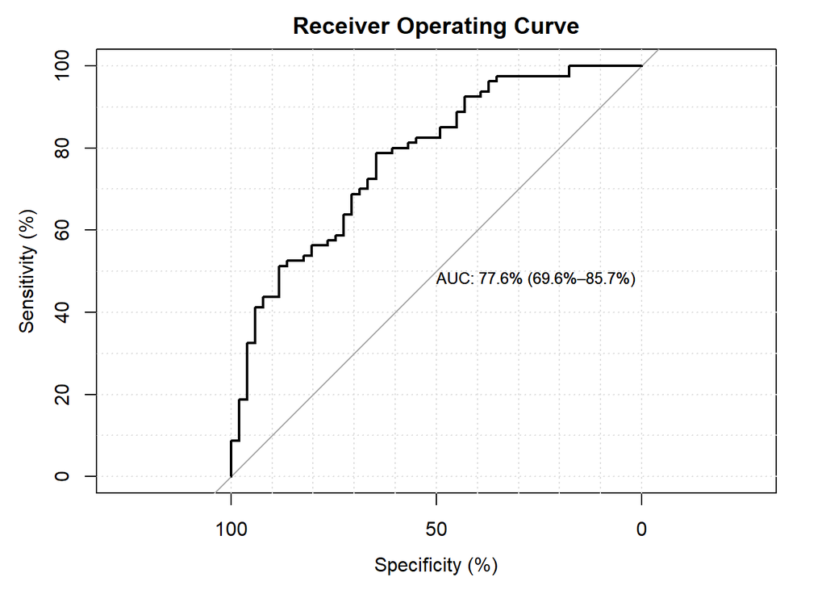

```
##          auc lower 95% CI upper 95% CI
##     77.64706     69.56149     85.73263
## attr(,"interpret")
## [1] "auc = 0.5       --> useless"   "0.7 < auc < 0.8 --> good"
## [3] "0.8 < auc < 0.9 --> excellent"
```

```r
# AUC
gof(modelClinicalA)$auc
```

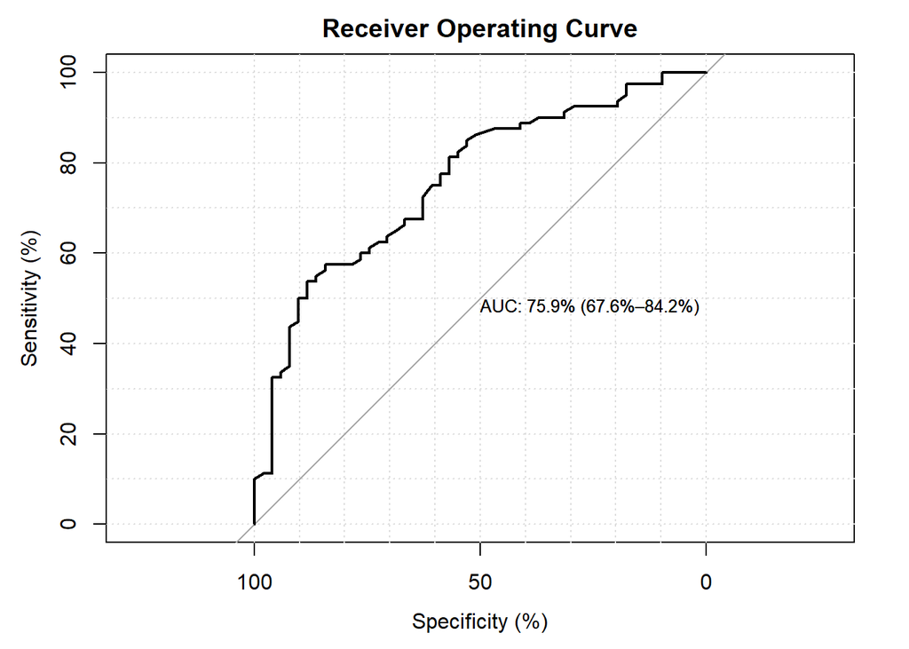

```
##          auc lower 95% CI upper 95% CI
##     75.91912     67.59951     84.23873
## attr(,"interpret")
## [1] "auc = 0.5       --> useless"   "0.7 < auc < 0.8 --> good"
## [3] "0.8 < auc < 0.9 --> excellent"
```

```r
gof(modelClinicalB)$auc
```

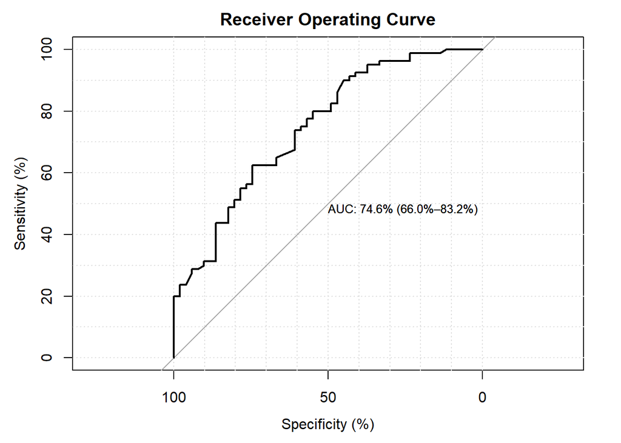

```
##          auc lower 95% CI upper 95% CI
##     74.60784     66.02381     83.19187
## attr(,"interpret")
## [1] "auc = 0.5       --> useless"   "0.7 < auc < 0.8 --> good"
## [3] "0.8 < auc < 0.9 --> excellent"
```

```r
gof(modelClinicalC)$auc
```

```r
# PPV/NPV
precision(dataClinical$lives, probTrainClinicalA, threshold = modelClinicalA.cut)
```

```
## [1] 0.7027027
```

```r
npv(dataClinical$lives, probTrainClinicalA, threshold = modelClinicalA.cut)
```

```
## [1] 0.9
```

```r
precision(dataClinical$lives, probTrainClinicalB, threshold = modelClinicalB.cut)
```

```
## [1] 0.7340426
```

```r
npv(dataClinical$lives, probTrainClinicalB, threshold = modelClinicalB.cut)
```

```
## [1] 0.7027027
```

```r
precision(dataClinical$lives, probTrainClinicalC, threshold = modelClinicalC.cut)
```

```
## [1] 0.7115385
```

```r
npv(dataClinical$lives, probTrainClinicalC, threshold = modelClinicalC.cut)
```

```
## [1] 0.7777778
```

```r
# Best Clinical model
modelClinical <- modelClinicalB
```

- The clinical model selected by stepwise regression and best subsets are very similar in performance

| Model | A | B | C |
| --- | --- | --- | --- |
| Accuracy | 0.73 | 0.73 | 0.73 |
| AUC | 0.78 [0.70-0.86] | 0.76 [0.68-0.84] | 0.75 [0.66-0.83] |
| PPV | 0.70 | 0.73 | 0.71 |
| NPV | 0.90 | 0.70 | 0.78 |

- Clinical model B has slighter higher PPV

# Build the tumor/liver model

### Correlation matrix for tumor/liver variables

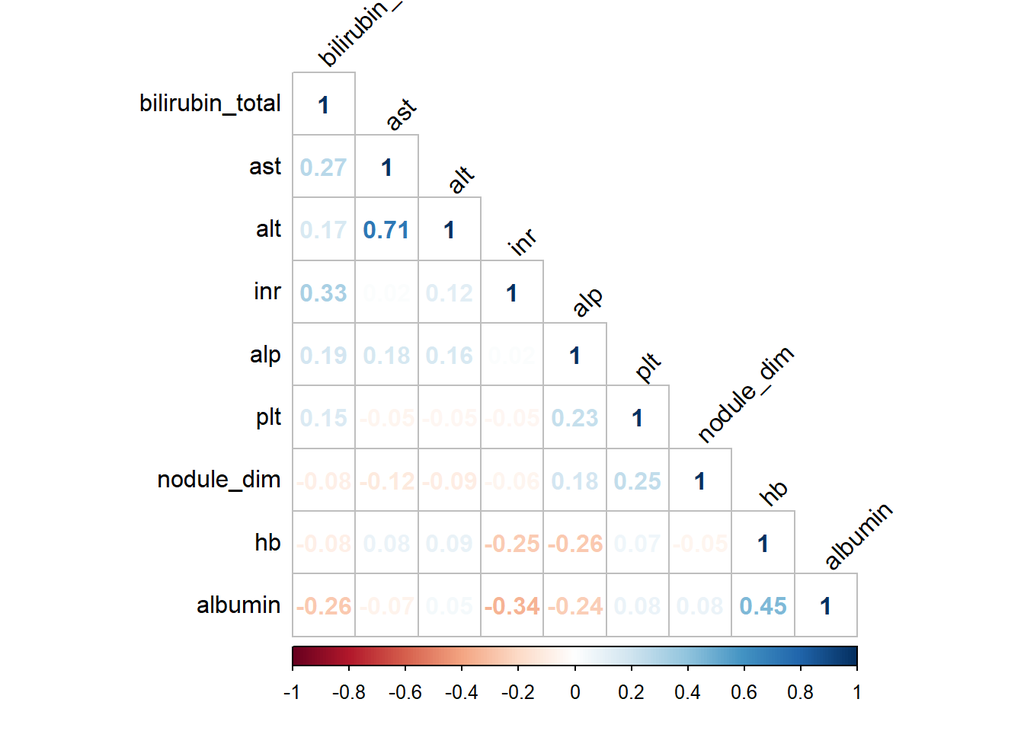

```r
corrplot(cor(dataTrain %>%
                 dplyr::select(one_of(varsBCLC)) %>%
                 dplyr::select_if(is.numeric),
             use = "pairwise.complete.obs"),
         method = "number",
         type = "lower", order = "FPC", tl.col = "black", tl.srt = 45)
```

### Univariate logistic regressions

```r
glmUnivarBCLC <- cbind(varsBCLC,
                       setNames(data.frame(matrix(nrow = length(varsBCLC),
                                                  ncol = 3)),
                                c("OR_", "CI_", "pval")))

for (i in seq_along(varsBCLC)) {
    fit <- glm(as.formula(paste0("lives ~ ", varsBCLC[i])),
               data = dataTrain,
               family = binomial)
    beta <- coef(fit)
    ci <- confint(fit)
    pval <- coef(summary(fit))[2, 4]
    glmUnivarBCLC[i, 2] <- round(exp(beta[2]), 2)
    glmUnivarBCLC[i, 3] <- paste0("(", round(exp(ci[2,1]),2), " - ", round(exp(ci[2,2]),2), ")")
    glmUnivarBCLC[i, 4] <- round(pval,3)
}

print(glmUnivarBCLC)
```

```
##              varsBCLC  OR_                         CI_  pval
## 1           nodule_no 0.64               (0.23 - 1.84) 0.401
## 2          nodule_dim 0.92               (0.85 - 0.99) 0.023
## 3          metastasis 0.31               (0.12 - 0.75) 0.010
## 4            hallmark 0.90               (0.42 - 1.89) 0.778
## 5     bilirubin_total 0.83               (0.69 - 0.94) 0.023
## 6             albumin 2.63               (1.54 - 4.72) 0.001
## 7                 inr 0.34                (0.12 - 0.8) 0.027
## 8                  hb 1.41               (1.17 - 1.72) 0.000
## 9                 plt 1.00                     (1 - 1) 0.099
## 10            ascites 0.35               (0.14 - 0.79) 0.014
## 11     encephalopathy 0.00 (NA - 8.74231935974537e+36) 0.989
## 12                alt 1.00               (0.99 - 1.01) 0.977
## 13                ast 1.00                  (0.99 - 1) 0.096
## 14                alp 1.00                  (0.99 - 1) 0.006
## 15       splenomegaly 0.93               (0.46 - 1.89) 0.850
## 16 portalHypertension 0.80               (0.38 - 1.68) 0.567
## 17                pvt 0.35               (0.14 - 0.82) 0.017
## 18        performance 0.00 (NA - 2.38949027156728e+25) 0.986
```

```r
with(dataTrain, table(lives, nodule_no))
```

```
##      nodule_no
## lives  0  1  2  3  4  5
##     0  0 16  9  3  0 23
##     1  0 36 13  6  0 25
```

```r
with(dataTrain, table(lives, encephalopathy))
```

```
##      encephalopathy
## lives  1  2  3
##     0 40  7  4
##     1 73  7  0
```

```r
with(dataTrain, table(lives, performance))
```

```
##      performance
## lives  0  1  2  3  4
##     0 16  9 10 11  5
##     1 53 13 10  4  0
```

```r
predBCLC <- varsBCLC[!varsBCLC %in% c("encephalopathy")]
```

### Model selection via stepwise regression

```r
# Fit the full model
dataBCLC <- dataTrain %>%
    dplyr::select(one_of(predBCLC, "lives"))

fullModel.BCLC <- glm(lives ~ ., dataBCLC,
                      family = binomial)
summary(fullModel.BCLC)
```

```
##
## Call:
## glm(formula = lives ~ ., family = binomial, data = dataBCLC)
##
## Deviance Residuals:
##     Min       1Q   Median       3Q      Max
## -2.4704  -0.5775   0.1767   0.6397   2.5460
##
## Coefficients:
##                       Estimate Std. Error z value Pr(>|z|)
## (Intercept)         -6.577e+00  2.974e+02  -0.022  0.98236
## nodule_no2          -1.510e+00  7.810e-01  -1.933  0.05321 .
## nodule_no3           6.501e-01  1.217e+00   0.534  0.59328
## nodule_no5          -6.991e-01  7.854e-01  -0.890  0.37340
## nodule_dim          -8.840e-02  6.034e-02  -1.465  0.14290
## metastasis1         -8.237e-01  8.585e-01  -0.959  0.33732
## hallmark1            2.065e-01  5.865e-01   0.352  0.72483
## bilirubin_total     -1.243e-01  1.470e-01  -0.845  0.39809
## albumin              4.930e-02  4.594e-01   0.107  0.91454
## inr                 -5.852e-01  6.223e-01  -0.940  0.34703
## hb                   4.328e-01  1.657e-01   2.613  0.00898 **
## plt                 -4.799e-06  2.930e-06  -1.638  0.10144
## ascites.L           -1.672e+00  6.927e-01  -2.414  0.01578 *
## ascites.Q            6.874e-01  6.413e-01   1.072  0.28375
## alt                  1.298e-02  9.746e-03   1.331  0.18308
## ast                 -1.145e-02  5.601e-03  -2.045  0.04090 *
## alp                 -2.417e-03  1.630e-03  -1.482  0.13823
## splenomegaly1        4.491e-02  7.287e-01   0.062  0.95086
## portalHypertension1  1.751e+00  8.274e-01   2.117  0.03426 *
## pvt1                -8.066e-01  7.684e-01  -1.050  0.29383
## performance.L       -1.119e+01  9.403e+02  -0.012  0.99051
## performance.Q       -8.645e+00  7.947e+02  -0.011  0.99132
## performance.C       -3.397e+00  4.702e+02  -0.007  0.99424
## performance^4       -1.091e+00  1.777e+02  -0.006  0.99510
## ---
## Signif. codes:  0 '***' 0.001 '**' 0.01 '*' 0.05 '.' 0.1 ' ' 1
##
## (Dispersion parameter for binomial family taken to be 1)
##
##     Null deviance: 175.13  on 130  degrees of freedom
## Residual deviance: 102.72  on 107  degrees of freedom
## AIC: 150.72
##
## Number of Fisher Scoring iterations: 16
```

```r
# Model via stepwise regression
modelBCLCA <- stepAIC(fullModel.BCLC,
                      direction = "both",
                      trace = FALSE)

summary(modelBCLCA)
```

```
##
## Call:
## glm(formula = lives ~ metastasis + hb + plt + ascites + ast +
##     alp + portalHypertension + pvt + performance, family = binomial,
##     data = dataBCLC)
##
## Deviance Residuals:
##     Min       1Q   Median       3Q      Max
## -2.3587  -0.7530   0.2619   0.6665   2.2549
##
## Coefficients:
##                       Estimate Std. Error z value Pr(>|z|)
## (Intercept)         -7.315e+00  3.015e+02  -0.024  0.98064
## metastasis1         -1.193e+00  5.981e-01  -1.995  0.04604 *
## hb                   3.915e-01  1.434e-01   2.730  0.00634 **
## plt                 -5.609e-06  2.597e-06  -2.160  0.03080 *
## ascites.L           -1.412e+00  6.120e-01  -2.308  0.02101 *
## ascites.Q            7.665e-01  5.608e-01   1.367  0.17168
## ast                 -4.701e-03  2.805e-03  -1.676  0.09376 .
## alp                 -2.668e-03  1.520e-03  -1.755  0.07927 .
## portalHypertension1  1.333e+00  6.323e-01   2.108  0.03502 *
## pvt1                -1.350e+00  6.753e-01  -1.999  0.04561 *
## performance.L       -1.184e+01  9.533e+02  -0.012  0.99009
## performance.Q       -9.280e+00  8.057e+02  -0.012  0.99081
## performance.C       -3.709e+00  4.767e+02  -0.008  0.99379
## performance^4       -1.421e+00  1.802e+02  -0.008  0.99371
## ---
## Signif. codes:  0 '***' 0.001 '**' 0.01 '*' 0.05 '.' 0.1 ' ' 1
##
## (Dispersion parameter for binomial family taken to be 1)
##
##     Null deviance: 175.13  on 130  degrees of freedom
## Residual deviance: 113.85  on 117  degrees of freedom
## AIC: 141.85
##
## Number of Fisher Scoring iterations: 16
```

### Model selection via best subsets

```r
dataBCLC.Xy <- dataBCLC %>%
    mutate_all(as.character) %>%
    mutate_all(as.numeric) %>%
    dplyr::select(-c(performance, alp)) %>%  # max p = 15
    rename(y = lives)

modelBCLC.bestglm <- bestglm(dataBCLC.Xy,
                             family = binomial, TopModels = 1,
                             IC = "BIC", method = "exhaustive")

modelBCLCB <- modelBCLC.bestglm$BestModel

summary(modelBCLCB)
```

```
##
## Call:
## glm(formula = y ~ ., family = family, data = Xi, weights = weights)
##
## Deviance Residuals:
##     Min       1Q   Median       3Q      Max
## -2.2622  -0.9348   0.4719   0.8097   1.6362
##
## Coefficients:
##                 Estimate Std. Error z value Pr(>|z|)
## (Intercept)     -0.82870    1.53576  -0.540  0.58947
## nodule_dim      -0.12441    0.04244  -2.931  0.00338 **
## bilirubin_total -0.18287    0.08998  -2.032  0.04211 *
## hb               0.29285    0.10672   2.744  0.00607 **
## ascites         -0.76078    0.31353  -2.427  0.01525 *
## ---
## Signif. codes:  0 '***' 0.001 '**' 0.01 '*' 0.05 '.' 0.1 ' ' 1
##
## (Dispersion parameter for binomial family taken to be 1)
##
##     Null deviance: 175.13  on 130  degrees of freedom
## Residual deviance: 137.92  on 126  degrees of freedom
## AIC: 147.92
##
## Number of Fisher Scoring iterations: 5
```

```r
modelBCLCB <- glm(lives ~ nodule_dim + bilirubin_total + hb + ascites,
                 dataBCLC,
                 family = "binomial")
```

### Random forest for feature selection

`randomForest` used to select predictors for `glmulti`

```r
set.seed(seed)
rForestBCLC <- randomForest(lives ~ ., dataBCLC, importance = TRUE)
importance(rForestBCLC)
```

```
##                              0           1 MeanDecreaseAccuracy
## nodule_no          -2.04588357 -0.20232558           -1.5490205
## nodule_dim          2.95188983  4.81564437            5.3346672
## metastasis          2.36362335  4.60036163            4.3960538
## hallmark           -1.26143558 -0.82825492           -1.2904533
## bilirubin_total     2.18857970  1.66191075            2.7817037
## albumin             3.23133719  8.73125421            8.7900899
## inr                -1.45851118  1.46566346            0.1102496
## hb                  9.49588295  9.36324397           12.1680568
## plt                -0.04449088  4.67993553            3.4197148
## ascites            -0.25437480  4.79334709            3.3310253
## alt                 1.59302305  0.09210355            1.0958154
## ast                 3.81982322  1.01989238            3.3527689
## alp                 5.55605367  2.70164189            5.5116907
## splenomegaly       -0.49045479  0.09942376           -0.4400285
## portalHypertension -1.35355857 -1.09980883           -1.8359670
## pvt                -0.81831896  1.59079948            0.8213835
## performance         4.52726887  8.92593024            9.2066091
##                    MeanDecreaseGini
## nodule_no                 1.5830313
## nodule_dim                5.7381585
## metastasis                0.9452898
## hallmark                  0.4932227
## bilirubin_total           4.3601618
## albumin                   6.3543747
## inr                       4.3359006
## hb                        8.9396491
## plt                       4.7776335
## ascites                   2.5678029
## alt                       3.1641843
## ast                       5.2878014
## alp                       7.5709654
## splenomegaly              0.3979704
## portalHypertension        0.4906042
## pvt                       0.7781835
## performance               4.0002024
```

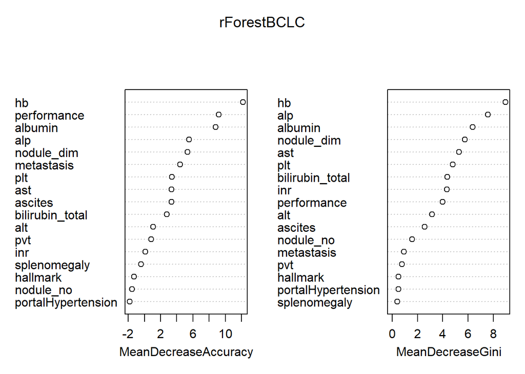

```r
varImpPlot(rForestBCLC)
```

### Model selection via automated model selection and model-averaging

Selected the top 12 predictors as per random forest for `glmulti`

```r
# Model via automated model selection and model-averaging
modelBCLC.glmulti <- glmulti(lives ~ hb + performance + albumin + alp +
                                 nodule_dim + metastasis + plt + ast +
                                 ascites + bilirubin_total + alt + pvt,
                             data = dataBCLC,
                             level = 1,
                             crit = "bic",
                             confsetsize = 1,
                             fitfunction = "glm",
                             family = binomial)
```

```
## Initialization...
## TASK: Exhaustive screening of candidate set.
## Fitting...
##
## After 50 models:
## Best model: lives~1+hb+albumin+nodule_dim+ast
## Crit= 168.038766209737
## Mean crit= 168.038766209737
```

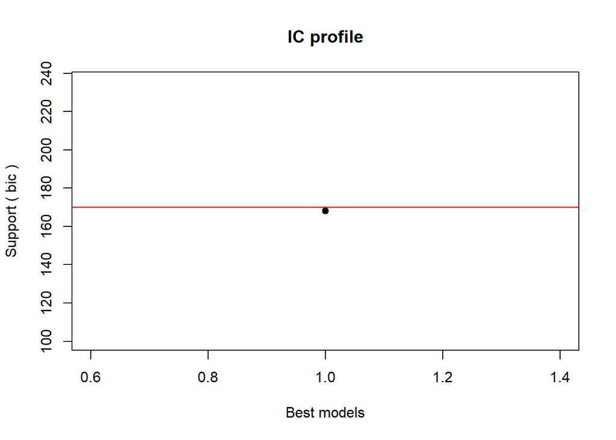

```
##
## After 100 models:
## Best model: lives~1+hb+nodule_dim+bilirubin_total
## Crit= 163.60893885409
## Mean crit= 163.60893885409
```

```
##
## After 150 models:
## Best model: lives~1+hb+nodule_dim+bilirubin_total
## Crit= 163.60893885409
## Mean crit= 163.60893885409
```

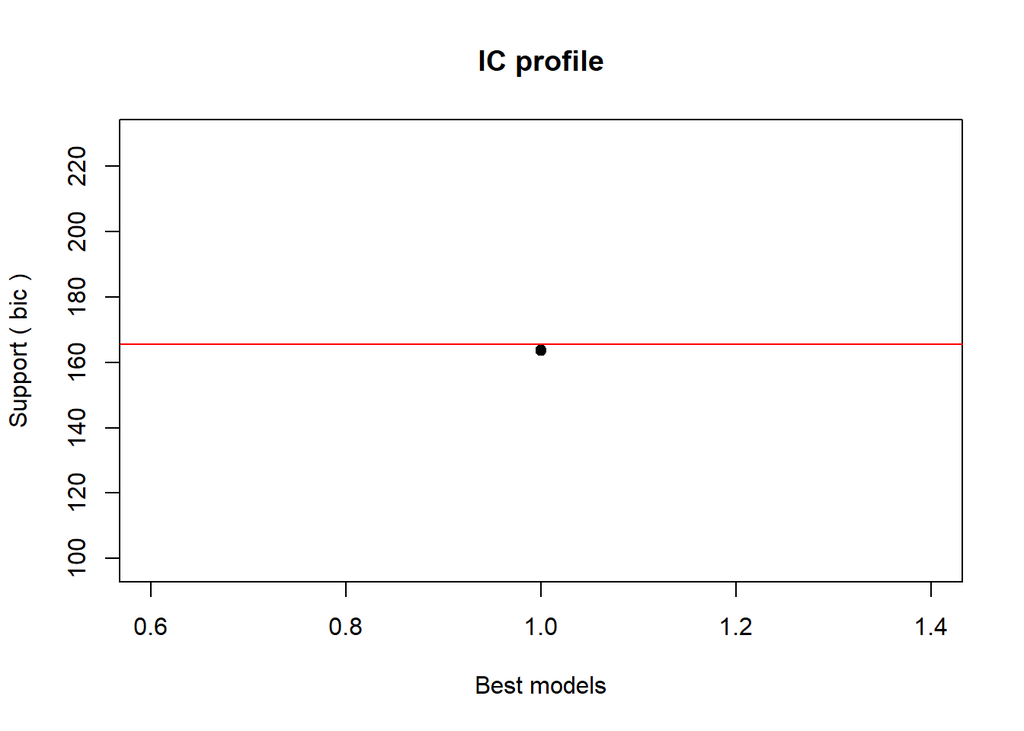

```
##
## After 200 models:
## Best model: lives~1+hb+nodule_dim+bilirubin_total
## Crit= 163.60893885409
## Mean crit= 163.60893885409
```

```
##
## After 250 models:
## Best model: lives~1+hb+nodule_dim+bilirubin_total
## Crit= 163.60893885409
## Mean crit= 163.60893885409
```

```
##
## After 300 models:
## Best model: lives~1+hb+nodule_dim+bilirubin_total
## Crit= 163.60893885409
## Mean crit= 163.60893885409
```

```
##
## After 350 models:
## Best model: lives~1+hb+nodule_dim+bilirubin_total
## Crit= 163.60893885409
## Mean crit= 163.60893885409
```

```
##
## After 400 models:
## Best model: lives~1+hb+nodule_dim+bilirubin_total
## Crit= 163.60893885409
## Mean crit= 163.60893885409
```

```
##
## After 450 models:
## Best model: lives~1+hb+nodule_dim+bilirubin_total
## Crit= 163.60893885409
## Mean crit= 163.60893885409
```

```
##
## After 500 models:
## Best model: lives~1+hb+nodule_dim+bilirubin_total
## Crit= 163.60893885409
## Mean crit= 163.60893885409
```

```
##
## After 550 models:
## Best model: lives~1+hb+nodule_dim+bilirubin_total
## Crit= 163.60893885409
## Mean crit= 163.60893885409
```

```
##
## After 600 models:
## Best model: lives~1+metastasis+hb+bilirubin_total
## Crit= 163.535022178082
## Mean crit= 163.535022178082
```

```
##
## After 650 models:
## Best model: lives~1+metastasis+hb+bilirubin_total
## Crit= 163.535022178082
## Mean crit= 163.535022178082
```

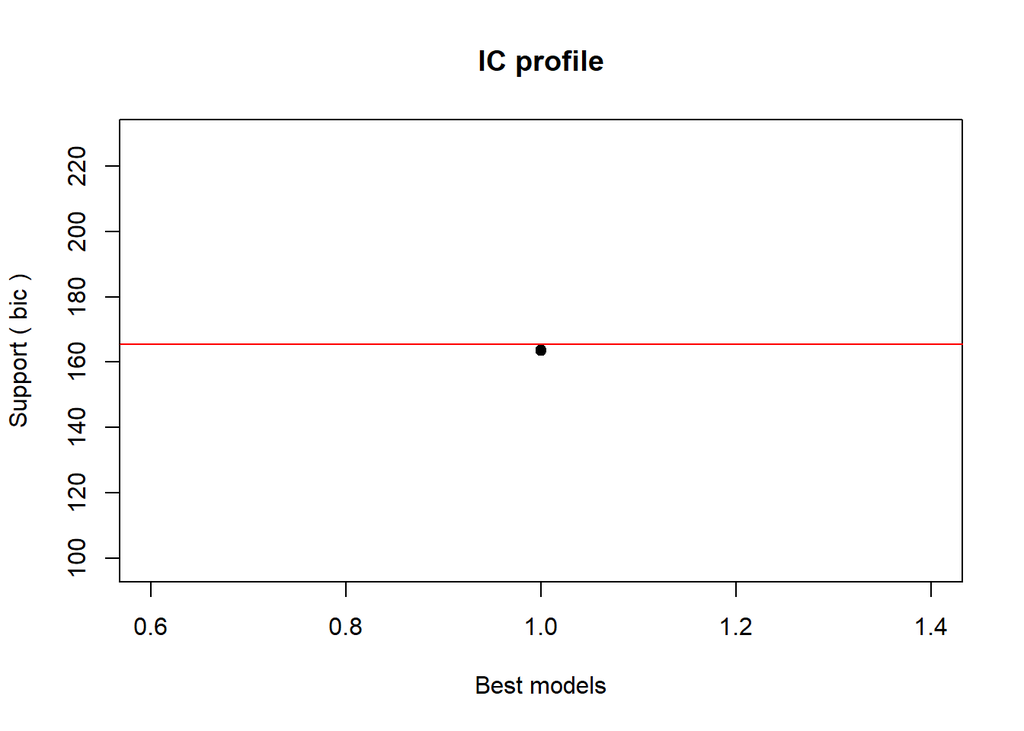

```
##
## After 700 models:
## Best model: lives~1+metastasis+hb+bilirubin_total
## Crit= 163.535022178082
## Mean crit= 163.535022178082
```

```
##
## After 750 models:
## Best model: lives~1+metastasis+hb+bilirubin_total
## Crit= 163.535022178082
## Mean crit= 163.535022178082
```

```
##
## After 800 models:
## Best model: lives~1+metastasis+hb+bilirubin_total
## Crit= 163.535022178082
## Mean crit= 163.535022178082
```

```
##
## After 850 models:
## Best model: lives~1+metastasis+hb+bilirubin_total
## Crit= 163.535022178082
## Mean crit= 163.535022178082
```

```
##
## After 900 models:
## Best model: lives~1+metastasis+hb+bilirubin_total
## Crit= 163.535022178082
## Mean crit= 163.535022178082
```

```
##
## After 950 models:
## Best model: lives~1+metastasis+hb+bilirubin_total
## Crit= 163.535022178082
## Mean crit= 163.535022178082
```

```
##
## After 1000 models:
## Best model: lives~1+metastasis+hb+bilirubin_total
## Crit= 163.535022178082
## Mean crit= 163.535022178082
```

```
##
## After 1050 models:
## Best model: lives~1+metastasis+hb+bilirubin_total
## Crit= 163.535022178082
## Mean crit= 163.535022178082
```

```
##
## After 1100 models:
## Best model: lives~1+metastasis+hb+bilirubin_total
## Crit= 163.535022178082
## Mean crit= 163.535022178082
```

```
##
## After 1150 models:
## Best model: lives~1+metastasis+hb+bilirubin_total
## Crit= 163.535022178082
## Mean crit= 163.535022178082
```

```
##
## After 1200 models:
## Best model: lives~1+metastasis+hb+bilirubin_total
## Crit= 163.535022178082
## Mean crit= 163.535022178082
```

```
##
## After 1250 models:
## Best model: lives~1+metastasis+hb+bilirubin_total
## Crit= 163.535022178082
## Mean crit= 163.535022178082
```

```
##
## After 1300 models:
## Best model: lives~1+metastasis+hb+bilirubin_total
## Crit= 163.535022178082
## Mean crit= 163.535022178082
```

```
##
## After 1350 models:
## Best model: lives~1+metastasis+hb+bilirubin_total
## Crit= 163.535022178082
## Mean crit= 163.535022178082
```

```
##
## After 1400 models:
## Best model: lives~1+metastasis+hb+bilirubin_total
## Crit= 163.535022178082
## Mean crit= 163.535022178082
```

```
##
## After 1450 models:
## Best model: lives~1+metastasis+hb+bilirubin_total
## Crit= 163.535022178082
## Mean crit= 163.535022178082
```

```
##
## After 1500 models:
## Best model: lives~1+metastasis+hb+bilirubin_total
## Crit= 163.535022178082
## Mean crit= 163.535022178082
```

```
##
## After 1550 models:
## Best model: lives~1+metastasis+hb+bilirubin_total
## Crit= 163.535022178082
## Mean crit= 163.535022178082
```

```
##
## After 1600 models:
## Best model: lives~1+metastasis+hb+bilirubin_total
## Crit= 163.535022178082
## Mean crit= 163.535022178082
```

```
##
## After 1650 models:
## Best model: lives~1+metastasis+hb+bilirubin_total
## Crit= 163.535022178082
## Mean crit= 163.535022178082
```

```
##
## After 1700 models:
## Best model: lives~1+metastasis+hb+bilirubin_total
## Crit= 163.535022178082
## Mean crit= 163.535022178082
```

```
##
## After 1750 models:
## Best model: lives~1+metastasis+hb+bilirubin_total
## Crit= 163.535022178082
## Mean crit= 163.535022178082
```

```
##
## After 1800 models:
## Best model: lives~1+metastasis+hb+bilirubin_total
## Crit= 163.535022178082
## Mean crit= 163.535022178082
```

```
##
## After 1850 models:
## Best model: lives~1+metastasis+hb+bilirubin_total
## Crit= 163.535022178082
## Mean crit= 163.535022178082
```

```
##
## After 1900 models:
## Best model: lives~1+metastasis+hb+bilirubin_total
## Crit= 163.535022178082
## Mean crit= 163.535022178082
```

```
##
## After 1950 models:
## Best model: lives~1+metastasis+hb+bilirubin_total
## Crit= 163.535022178082
## Mean crit= 163.535022178082
```

```
##
## After 2000 models:
## Best model: lives~1+metastasis+hb+bilirubin_total
## Crit= 163.535022178082
## Mean crit= 163.535022178082
```

```
##
## After 2050 models:
## Best model: lives~1+metastasis+hb+bilirubin_total
## Crit= 163.535022178082
## Mean crit= 163.535022178082
```

```
##
## After 2100 models:
## Best model: lives~1+metastasis+hb+bilirubin_total
## Crit= 163.535022178082
## Mean crit= 163.535022178082
```

```
##
## After 2150 models:
## Best model: lives~1+metastasis+hb+bilirubin_total
## Crit= 163.535022178082
## Mean crit= 163.535022178082
```

```
##
## After 2200 models:
## Best model: lives~1+metastasis+hb+bilirubin_total
## Crit= 163.535022178082
## Mean crit= 163.535022178082
```

```
##
## After 2250 models:
## Best model: lives~1+metastasis+hb+bilirubin_total
## Crit= 163.535022178082
## Mean crit= 163.535022178082
```

```
##
## After 2300 models:
## Best model: lives~1+metastasis+hb+bilirubin_total
## Crit= 163.535022178082
## Mean crit= 163.535022178082
```

```
##
## After 2350 models:
## Best model: lives~1+metastasis+hb+bilirubin_total
## Crit= 163.535022178082
## Mean crit= 163.535022178082
```

```
##
## After 2400 models:
## Best model: lives~1+metastasis+hb+bilirubin_total
## Crit= 163.535022178082
## Mean crit= 163.535022178082
```

```
##
## After 2450 models:
## Best model: lives~1+metastasis+hb+bilirubin_total
## Crit= 163.535022178082
## Mean crit= 163.535022178082
```

```
##
## After 2500 models:
## Best model: lives~1+metastasis+hb+bilirubin_total
## Crit= 163.535022178082
## Mean crit= 163.535022178082
```

```
##
## After 2550 models:
## Best model: lives~1+metastasis+hb+bilirubin_total
## Crit= 163.535022178082
## Mean crit= 163.535022178082
```

```
##
## After 2600 models:
## Best model: lives~1+metastasis+hb+bilirubin_total
## Crit= 163.535022178082
## Mean crit= 163.535022178082
```

```
##
## After 2650 models:
## Best model: lives~1+metastasis+hb+bilirubin_total
## Crit= 163.535022178082
## Mean crit= 163.535022178082
```

```
##
## After 2700 models:
## Best model: lives~1+metastasis+hb+bilirubin_total
## Crit= 163.535022178082
## Mean crit= 163.535022178082
```

```
##
## After 2750 models:
## Best model: lives~1+metastasis+hb+bilirubin_total
## Crit= 163.535022178082
## Mean crit= 163.535022178082
```

```
##
## After 2800 models:
## Best model: lives~1+metastasis+hb+bilirubin_total
## Crit= 163.535022178082
## Mean crit= 163.535022178082
```

```
##
## After 2850 models:
## Best model: lives~1+metastasis+hb+bilirubin_total
## Crit= 163.535022178082
## Mean crit= 163.535022178082
```

```
##
## After 2900 models:
## Best model: lives~1+metastasis+hb+bilirubin_total
## Crit= 163.535022178082
## Mean crit= 163.535022178082
```

```
##
## After 2950 models:
## Best model: lives~1+metastasis+hb+bilirubin_total
## Crit= 163.535022178082
## Mean crit= 163.535022178082
```

```
##
## After 3000 models:
## Best model: lives~1+metastasis+hb+bilirubin_total
## Crit= 163.535022178082
## Mean crit= 163.535022178082
```

```
##
## After 3050 models:
## Best model: lives~1+metastasis+hb+bilirubin_total
## Crit= 163.535022178082
## Mean crit= 163.535022178082
```

```
##
## After 3100 models:
## Best model: lives~1+metastasis+hb+bilirubin_total
## Crit= 163.535022178082
## Mean crit= 163.535022178082
```

```
##
## After 3150 models:
## Best model: lives~1+metastasis+hb+bilirubin_total
## Crit= 163.535022178082
## Mean crit= 163.535022178082
```

```
##
## After 3200 models:
## Best model: lives~1+metastasis+hb+bilirubin_total
## Crit= 163.535022178082
## Mean crit= 163.535022178082
```

```
##
## After 3250 models:
## Best model: lives~1+metastasis+hb+bilirubin_total
## Crit= 163.535022178082
## Mean crit= 163.535022178082
```

```
##
## After 3300 models:
## Best model: lives~1+metastasis+hb+bilirubin_total
## Crit= 163.535022178082
## Mean crit= 163.535022178082
```

```
##
## After 3350 models:
## Best model: lives~1+metastasis+hb+bilirubin_total
## Crit= 163.535022178082
## Mean crit= 163.535022178082
```

```
##
## After 3400 models:
## Best model: lives~1+metastasis+hb+bilirubin_total
## Crit= 163.535022178082
## Mean crit= 163.535022178082
```

```
##
## After 3450 models:
## Best model: lives~1+metastasis+hb+bilirubin_total
## Crit= 163.535022178082
## Mean crit= 163.535022178082
```

```
##
## After 3500 models:
## Best model: lives~1+metastasis+hb+bilirubin_total
## Crit= 163.535022178082
## Mean crit= 163.535022178082
```

```
##
## After 3550 models:
## Best model: lives~1+metastasis+hb+bilirubin_total
## Crit= 163.535022178082
## Mean crit= 163.535022178082
```

```
##
## After 3600 models:
## Best model: lives~1+metastasis+hb+bilirubin_total
## Crit= 163.535022178082
## Mean crit= 163.535022178082
```

```
##
## After 3650 models:
## Best model: lives~1+metastasis+hb+bilirubin_total
## Crit= 163.535022178082
## Mean crit= 163.535022178082
```

```
##
## After 3700 models:
## Best model: lives~1+metastasis+hb+bilirubin_total
## Crit= 163.535022178082
## Mean crit= 163.535022178082
```

```
##
## After 3750 models:
## Best model: lives~1+metastasis+hb+bilirubin_total
## Crit= 163.535022178082
## Mean crit= 163.535022178082
```

```
##
## After 3800 models:
## Best model: lives~1+metastasis+hb+bilirubin_total
## Crit= 163.535022178082
## Mean crit= 163.535022178082
```

```
##
## After 3850 models:
## Best model: lives~1+metastasis+hb+bilirubin_total
## Crit= 163.535022178082
## Mean crit= 163.535022178082
```

```
##
## After 3900 models:
## Best model: lives~1+metastasis+hb+bilirubin_total
## Crit= 163.535022178082
## Mean crit= 163.535022178082
```

```
##
## After 3950 models:
## Best model: lives~1+metastasis+hb+bilirubin_total
## Crit= 163.535022178082
## Mean crit= 163.535022178082
```

```
##
## After 4000 models:
## Best model: lives~1+metastasis+hb+bilirubin_total
## Crit= 163.535022178082
## Mean crit= 163.535022178082
```

```
##
## After 4050 models:
## Best model: lives~1+metastasis+hb+bilirubin_total
## Crit= 163.535022178082
## Mean crit= 163.535022178082
```

```
##
## After 4100 models:
## Best model: lives~1+metastasis+hb+bilirubin_total
## Crit= 163.535022178082
## Mean crit= 163.535022178082
```

```
##
## After 4150 models:
## Best model: lives~1+metastasis+hb+bilirubin_total
## Crit= 163.535022178082
## Mean crit= 163.535022178082
```

```
##
## After 4200 models:
## Best model: lives~1+metastasis+hb+bilirubin_total
## Crit= 163.535022178082
## Mean crit= 163.535022178082
```

```
##
## After 4250 models:
## Best model: lives~1+metastasis+hb+bilirubin_total
## Crit= 163.535022178082
## Mean crit= 163.535022178082
```

```
## Completed.
```

```r
print(modelBCLC.glmulti)
```

```
## glmulti.analysis
## Method: h / Fitting: glm / IC used: bic
## Level: 1 / Marginality: FALSE
## From 1 models:
## Best IC: 163.535022178082
## Best model:
## [1] "lives ~ 1 + metastasis + hb + bilirubin_total"
## Evidence weight: 1
## Worst IC: 163.535022178082
## 1 models within 2 IC units.
## 0 models to reach 95% of evidence weight.
```

```r
modelBCLCC <- glm(lives ~ metastasis + hb + bilirubin_total,
                  data = dataBCLC,
                  family = binomial)
summary(modelBCLCC)
```

```
##
## Call:
## glm(formula = lives ~ metastasis + hb + bilirubin_total, family = binomial,
##     data = dataBCLC)
##
## Deviance Residuals:
##     Min       1Q   Median       3Q      Max
## -2.4707  -1.0153   0.5651   0.8516   1.7152
##
## Coefficients:
##                 Estimate Std. Error z value Pr(>|z|)
## (Intercept)     -2.97813    1.32213  -2.253  0.02429 *
## metastasis1     -1.36129    0.49722  -2.738  0.00619 **
## hb               0.32897    0.10203   3.224  0.00126 **
## bilirubin_total -0.18871    0.08713  -2.166  0.03033 *
## ---
## Signif. codes:  0 '***' 0.001 '**' 0.01 '*' 0.05 '.' 0.1 ' ' 1
##
## (Dispersion parameter for binomial family taken to be 1)
##
##     Null deviance: 175.13  on 130  degrees of freedom
## Residual deviance: 144.03  on 127  degrees of freedom
## AIC: 152.03
##
## Number of Fisher Scoring iterations: 5
```

### Model error check

```r
# Multicollinearity
vif(modelBCLCA)
```

```
##                        GVIF Df GVIF^(1/(2*Df))
## metastasis         1.216971  1        1.103164
## hb                 1.390496  1        1.179193
## plt                1.351393  1        1.162494
## ascites            2.055008  2        1.197301
## ast                1.132792  1        1.064327
## alp                1.433488  1        1.197283
## portalHypertension 1.742419  1        1.320007
## pvt                1.481648  1        1.217230
## performance        2.755672  4        1.135085
```

```r
vif(modelBCLCB)
```

```
##                     GVIF Df GVIF^(1/(2*Df))
## nodule_dim      1.110653  1        1.053875
## bilirubin_total 1.125360  1        1.060830
## hb              1.012943  1        1.006451
## ascites         1.135415  2        1.032259
```

```r
vif(modelBCLCC)
```

```
##      metastasis              hb bilirubin_total
##        1.033302        1.016608        1.022708
```

```r
# Autocorrelation
durbinWatsonTest(modelBCLCA)
```

```
##  lag Autocorrelation D-W Statistic p-value
##    1      -0.1124165      2.200535   0.226
##  Alternative hypothesis: rho != 0
```

```r
durbinWatsonTest(modelBCLCB)
```

```
##  lag Autocorrelation D-W Statistic p-value
##    1      -0.1013351      2.189781   0.272
##  Alternative hypothesis: rho != 0
```

```r
durbinWatsonTest(modelBCLCC)
```

```
##  lag Autocorrelation D-W Statistic p-value
##    1     -0.08646486      2.163297    0.34
##  Alternative hypothesis: rho != 0
```

```r
# Check goodness of fit with Hosmer lemeshow
gof(modelBCLCA, plotROC = FALSE)$gof[1]
```

```
##    test  stat      val df      pVal
## 1:   HL chiSq 6.816797  8 0.5565219
```

```r
gof(modelBCLCB, plotROC = FALSE)$gof[1]
```

```
##    test  stat      val df      pVal
## 1:   HL chiSq 9.673351  8 0.2887048
```

```r
gof(modelBCLCC, plotROC = FALSE)$gof[1]
```

```
##    test  stat      val df      pVal
## 1:   HL chiSq 10.71016  8 0.2186691
```

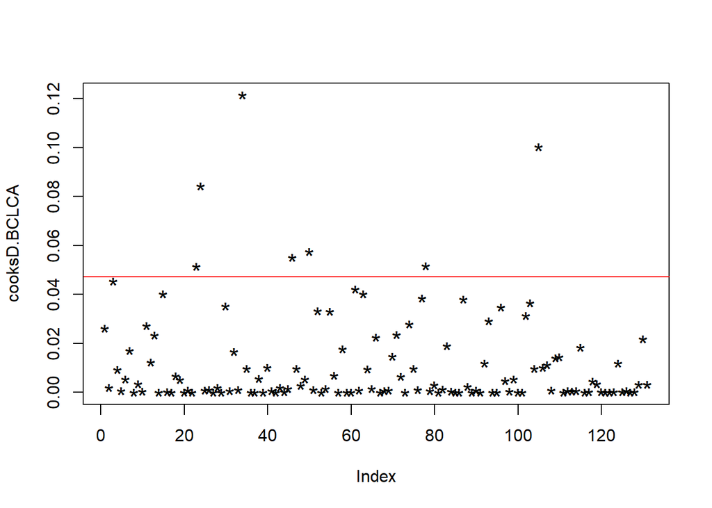

```r
# Review influential observations with Cook's Distance
cooksD.BCLCA <- cooks.distance(modelBCLCA)
plot(cooksD.BCLCA, pch = "*", cex = 1.5)
abline(h = 4*mean(cooksD.BCLCA, na.rm = TRUE), col = "red")
```

```r
influentialRows.BCLCA <- which(cooksD.BCLCA > 4*mean(cooksD.BCLCA, na.rm = TRUE))
dataBCLC %>%  # print influential observations
    dplyr::select(one_of(names(modelBCLCA$model)[-1])) %>%
    slice(influentialRows.BCLCA)
```

```
##   metastasis   hb    plt ascites ast alp portalHypertension pvt
## 1          0 12.2    108       1  85 293                  1   1
## 2          0  9.9    556       1 112 974                  0   0
## 3          0 15.7 188000       1 553  68                  0   0
## 4          0 18.7 270000       1  73 103                  0   0
## 5          0 12.6  76000       3  40 166                  1   0
## 6          0  9.1 307000       2  29 254                  1   0
## 7          1 14.9 179000       3  61 150                  0   1
##   performance
## 1           1
## 2           1
## 3           0
## 4           0
## 5           3
## 6           1
## 7           2
```

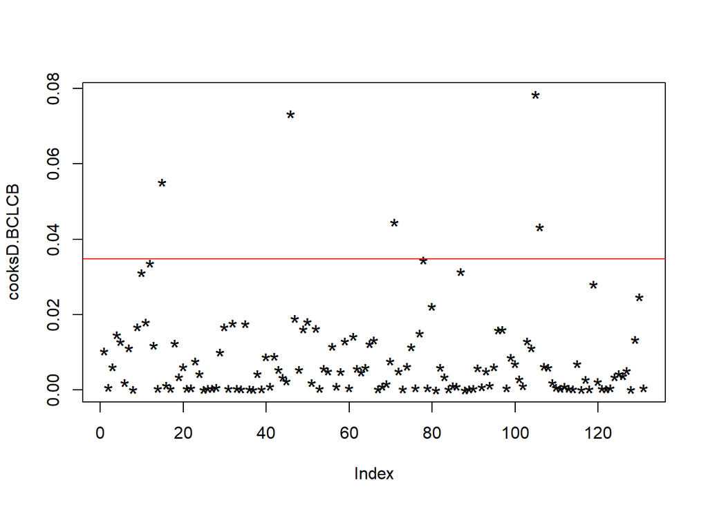

```r
cooksD.BCLCB <- cooks.distance(modelBCLCB)
plot(cooksD.BCLCB, pch = "*", cex = 1.5)
abline(h = 4*mean(cooksD.BCLCB, na.rm = TRUE), col = "red")
```

```r
influentialRows.BCLCB <- which(cooksD.BCLCB > 4*mean(cooksD.BCLCB, na.rm = TRUE))
dataBCLC %>%  # print influential observations
    dplyr::select(one_of(names(modelBCLCB$model)[-1])) %>%
    slice(influentialRows.BCLCB)
```

```
##   nodule_dim bilirubin_total   hb ascites
## 1        2.3             3.4 15.9       3
## 2       10.0             0.9 18.7       1
## 3        2.0             1.5  9.5       3
## 4       17.5             0.6 14.9       3
## 5        2.6             8.6 11.3       2
```

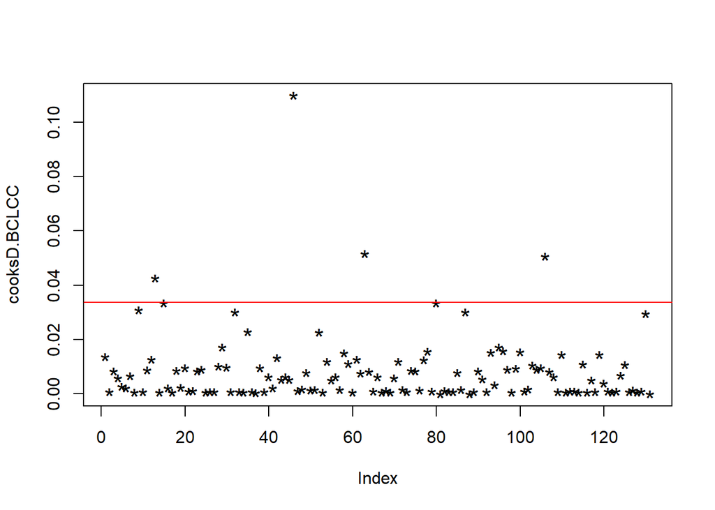

```r
cooksD.BCLCC <- cooks.distance(modelBCLCC)
plot(cooksD.BCLCC, pch = "*", cex = 1.5)
abline(h = 4*mean(cooksD.BCLCC, na.rm = TRUE), col = "red")
```

```r
influentialRows.BCLCC <- which(cooksD.BCLCC > 4*mean(cooksD.BCLCC, na.rm = TRUE))
dataBCLC %>%  # print influential observations
    dplyr::select(one_of(names(modelBCLCC$model)[-1])) %>%
    slice(influentialRows.BCLCC)
```

```
##   metastasis   hb bilirubin_total
## 1          1 10.3             0.5
## 2          0 18.7             0.9
## 3          1  9.8             0.5
## 4          0 11.3             8.6
```

- No multicollinearity: VIF < 4 for all predictors
- No autocorrelation: Durbin-Watson statistics > 2 for all predictors
- No lack of fit: Hosmer-Lemeshow p > 0.05
- Several influential observations were identified with Cook’s D but the observed values for the predictors are biologically possible and not true outliers so, in the interest of caution, they were not removed

### Model performance

```r
# Accuracy
probTrainBCLCA <- predict(modelBCLCA, type = "response")
modelBCLCA.cut <- optimalCutoff(dataBCLC$lives, probTrainBCLCA)
1 - misClassError(dataBCLC$lives, probTrainBCLCA, threshold = modelBCLCA.cut)
```

```
## [1] 0.7939
```

```r
probTrainBCLCB <- predict(modelBCLCB, type = "response")
modelBCLCB.cut <- optimalCutoff(dataBCLC$lives, probTrainBCLCB)
1 - misClassError(dataBCLC$lives, probTrainBCLCB, threshold = modelBCLCB.cut)
```

```
## [1] 0.7481
```

```r
probTrainBCLCC <- predict(modelBCLCC, type = "response")
modelBCLCC.cut <- optimalCutoff(dataBCLC$lives, probTrainBCLCC)
1 - misClassError(dataBCLC$lives, probTrainBCLCC, threshold = modelBCLCC.cut)
```

```
## [1] 0.7176
```

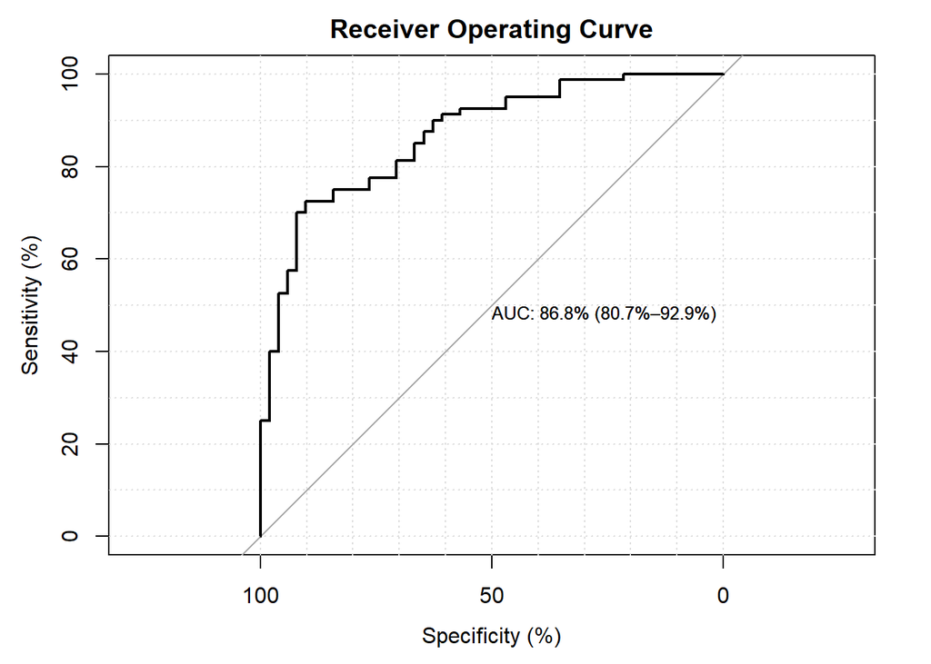

```
##          auc lower 95% CI upper 95% CI
##     86.78922     80.71049     92.86794
## attr(,"interpret")
## [1] "auc = 0.5       --> useless"   "0.7 < auc < 0.8 --> good"
## [3] "0.8 < auc < 0.9 --> excellent"
```

```r
# AUC
gof(modelBCLCA)$auc
```

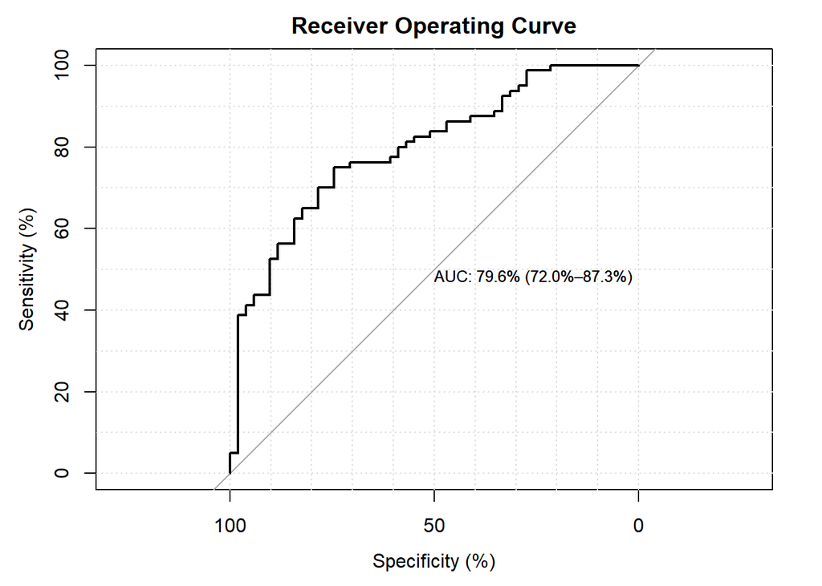

```
##          auc lower 95% CI upper 95% CI
##     79.60784     71.95662     87.25907
## attr(,"interpret")
## [1] "auc = 0.5       --> useless"   "0.7 < auc < 0.8 --> good"
## [3] "0.8 < auc < 0.9 --> excellent"
```

```r
gof(modelBCLCB)$auc
```

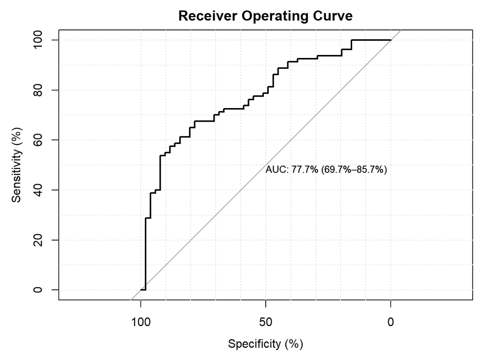

```
##          auc lower 95% CI upper 95% CI
##     77.72059     69.71889     85.72229
## attr(,"interpret")
## [1] "auc = 0.5       --> useless"   "0.7 < auc < 0.8 --> good"
## [3] "0.8 < auc < 0.9 --> excellent"
```

```r
gof(modelBCLCC)$auc
```

```r
# PPV/NPV
precision(dataBCLC$lives, probTrainBCLCA, threshold = modelBCLCA.cut)
```

```
## [1] 0.7849462
```

```r
npv(dataBCLC$lives, probTrainBCLCA, threshold = modelBCLCA.cut)
```

```
## [1] 0.8157895
```

```r
precision(dataBCLC$lives, probTrainBCLCB, threshold = modelBCLCB.cut)
```

```
## [1] 0.8219178
```

```r
npv(dataBCLC$lives, probTrainBCLCB, threshold = modelBCLCB.cut)
```

```
## [1] 0.6551724
```

```r
precision(dataBCLC$lives, probTrainBCLCC, threshold = modelBCLCC.cut)
```

```
## [1] 0.7087379
```

```r
npv(dataBCLC$lives, probTrainBCLCC, threshold = modelBCLCC.cut)
```

```
## [1] 0.75
```

```r
# Best BCLC model
modelBCLC <- modelBCLCB
```

[output not shown]

- Tumor/liver model B has a higher PPV which would mean the fewer false positives

# Build the molecular biomarker model

### Correlation matrix for molecular variables

```r
with(dataTrain, cor(afp, ggt, use = "pairwise.complete.obs"))
```

```
## [1] 0.06416174
```

### Univariate logistic regressions

```r
glmUnivarMarker <- cbind(varsMarker,
                         setNames(data.frame(matrix(nrow = length(varsMarker),
                                                    ncol = 3)),
                                  c("OR_", "CI_", "pval")))

for (i in seq_along(varsMarker)) {
    fit <- glm(as.formula(paste0("lives ~ ", varsMarker[i])),
               data = dataTrain,
               family = binomial)
    beta <- coef(fit)
    ci <- confint(fit)
    pval <- coef(summary(fit))[2, 4]
    glmUnivarMarker[i, 2] <- round(exp(beta[2]), 2)
    glmUnivarMarker[i, 3] <- paste0("(", round(exp(ci[2,1]),2), " - ", round(exp(ci[2,2]),2), ")")
    glmUnivarMarker[i, 4] <- round(pval,3)
}

print(glmUnivarMarker)
```

```
##   varsMarker OR_     CI_  pval
## 1        afp   1 (1 - 1) 0.060
## 2        ggt   1 (1 - 1) 0.053
```

```r
predMarker <- varsMarker
```

### Build models

There are only two biomarkers, “afp” and “ggt”, so no model selection processes needed.

```r
# Fit models
dataMarker <- dataTrain %>%
    dplyr::select(one_of(predMarker, "lives"))

modelMarkerA <- glm(lives ~ afp,
                    data = dataMarker,
                    family = binomial)
modelMarkerB <- glm(lives ~ ggt,
                    data = dataMarker,
                    family = binomial)
modelMarkerC <- glm(lives ~ afp + ggt,
                    data = dataMarker,
                    family = binomial)
```

### Model error check

```r
# Multicollinearity
vif(modelMarkerC)
```

```
##      afp      ggt
## 1.000565 1.000565
```

```r
# Autocorrelation
durbinWatsonTest(modelMarkerA)
```

```
##  lag Autocorrelation D-W Statistic p-value
##    1        -0.11067      2.207514    0.25
##  Alternative hypothesis: rho != 0
```

```r
durbinWatsonTest(modelMarkerB)
```

```
##  lag Autocorrelation D-W Statistic p-value
##    1      -0.1386279      2.255094   0.152
##  Alternative hypothesis: rho != 0
```

```r
durbinWatsonTest(modelMarkerC)
```

```
##  lag Autocorrelation D-W Statistic p-value
##    1      -0.1155546      2.215589   0.204
##  Alternative hypothesis: rho != 0
```

```r
# Check goodness of fit with Hosmer lemeshow
gof(modelMarkerA, plotROC = FALSE)$gof[1]
```

```
##    test  stat      val df       pVal
## 1:   HL chiSq 15.20088  8 0.05535524
```

```r
gof(modelMarkerB, plotROC = FALSE)$gof[1]
```

```
##    test  stat      val df      pVal
## 1:   HL chiSq 5.287246  8 0.7264799
```

```r
gof(modelMarkerC, plotROC = FALSE)$gof[1]
```

```
##    test  stat      val df      pVal
## 1:   HL chiSq 9.138619  8 0.3307376
```

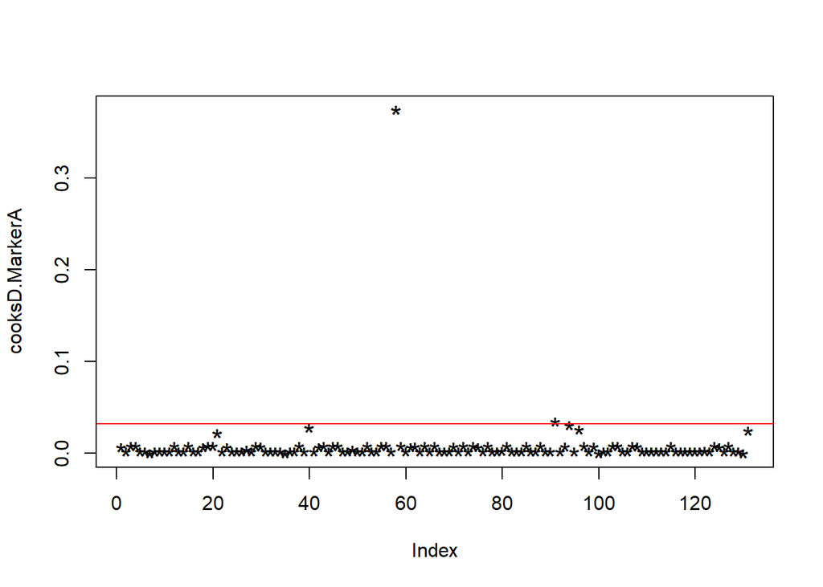

```r
# Review influential observations with Cook's Distance
cooksD.MarkerA <- cooks.distance(modelMarkerA)
plot(cooksD.MarkerA, pch = "*", cex = 1.5)
abline(h = 4*mean(cooksD.MarkerA, na.rm = TRUE), col = "red")
```

```r
influentialRows.MarkerA <- which(cooksD.MarkerA > 4*mean(cooksD.MarkerA, na.rm = TRUE))
dataMarker %>%  # print influential observations
    dplyr::select(one_of(names(modelMarkerA$model)[-1])) %>%
    slice(influentialRows.MarkerA)
```

```
##     afp
## 1 33502
## 2 28274
```

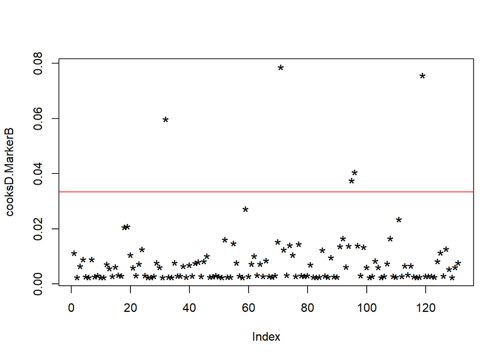

```r
cooksD.MarkerB <- cooks.distance(modelMarkerB)
plot(cooksD.MarkerB, pch = "*", cex = 1.5)
abline(h = 4*mean(cooksD.MarkerB, na.rm = TRUE), col = "red")
```

```r
influentialRows.MarkerB <- which(cooksD.MarkerB > 4*mean(cooksD.MarkerB, na.rm = TRUE))
dataMarker %>%  # print influential observations
    dplyr::select(one_of(names(modelMarkerB$model)[-1])) %>%
    slice(influentialRows.MarkerB)
```

```
##   ggt
## 1 924
## 2 993
## 3 816
## 4 833
## 5 983
```

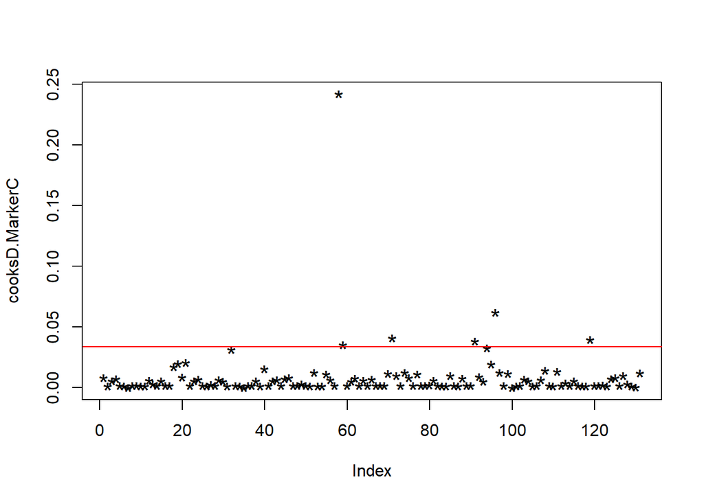

```r
cooksD.MarkerC <- cooks.distance(modelMarkerC)
plot(cooksD.MarkerC, pch = "*", cex = 1.5)
abline(h = 4*mean(cooksD.MarkerC, na.rm = TRUE), col = "red")
```

```r
influentialRows.MarkerC <- which(cooksD.MarkerB > 4*mean(cooksD.MarkerB, na.rm = TRUE))
dataMarker %>%  # print influential observations
    dplyr::select(one_of(names(modelMarkerC$model)[-1])) %>%
    slice(influentialRows.MarkerC)
```

```
##       afp ggt
## 1   479.0 924
## 2    20.0 993
## 3     5.2 816
## 4 14177.0 833
## 5     4.8 983
```

```r
data.imp %>%
    filter(afp > 100000) %>%
    dplyr::select(age, male, afp, lives)
```

```
##   age male     afp lives
## 1  41    1  100809     0
## 2  86    0  185203     0
## 3  59    1 1810346     1
## 4  76    1  421500     0
```

```r
# Accuracy
probTrainMarkerA <- predict(modelMarkerA, type = "response")
modelMarkerA.cut <- optimalCutoff(dataMarker$lives, probTrainMarkerA)
1 - misClassError(dataMarker$lives, probTrainMarkerA, threshold = modelMarkerA.cut)
```

```
## [1] 0.687
```

```r
probTrainMarkerB <- predict(modelMarkerB, type = "response")
modelMarkerB.cut <- optimalCutoff(dataMarker$lives, probTrainMarkerB)
1 - misClassError(dataMarker$lives, probTrainMarkerB, threshold = modelMarkerB.cut)
```

```
## [1] 0.6565
```

```r
probTrainMarkerC <- predict(modelMarkerC, type = "response")
modelMarkerC.cut <- optimalCutoff(dataMarker$lives, probTrainMarkerC)
1 - misClassError(dataMarker$lives, probTrainMarkerC, threshold = modelMarkerC.cut)
```

```
## [1] 0.6718
```

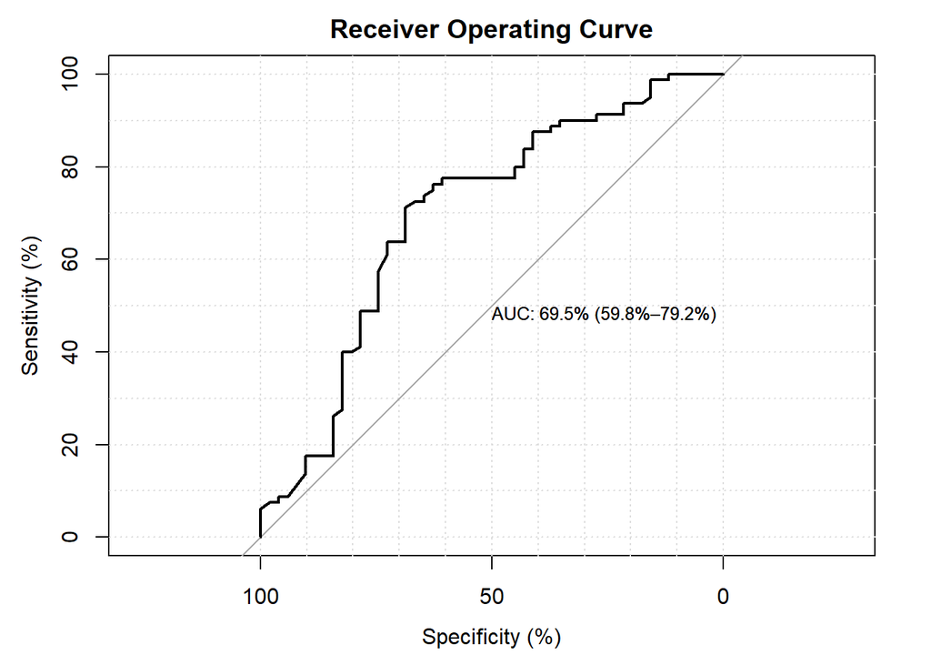

```
##          auc lower 95% CI upper 95% CI
##     69.52206     59.82785     79.21627
## attr(,"interpret")
## [1] "auc = 0.5       --> useless"   "0.7 < auc < 0.8 --> good"
## [3] "0.8 < auc < 0.9 --> excellent"
```

```r
# AUC
gof(modelMarkerA)$auc
```

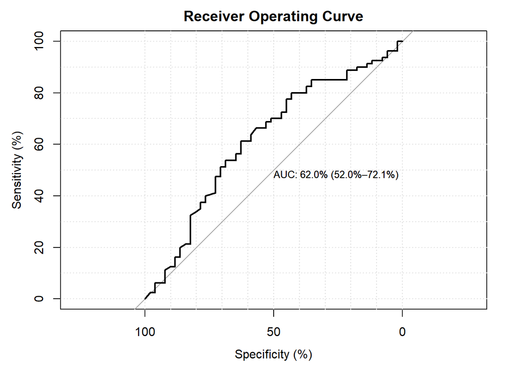

```
##          auc lower 95% CI upper 95% CI
##     62.03431     51.96635     72.10228
## attr(,"interpret")
## [1] "auc = 0.5       --> useless"   "0.7 < auc < 0.8 --> good"
## [3] "0.8 < auc < 0.9 --> excellent"
```

```r
gof(modelMarkerB)$auc
```

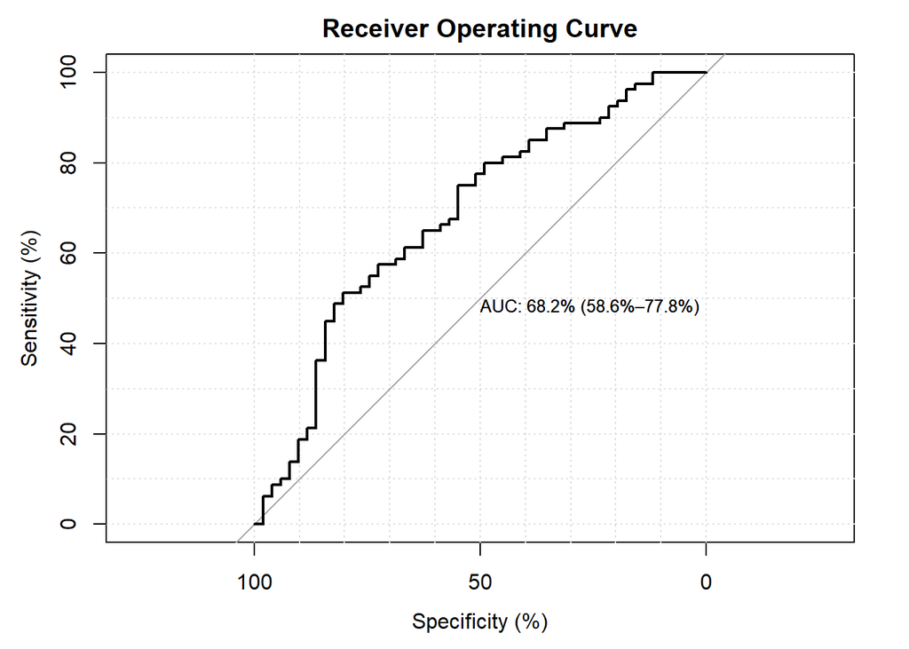

```
##          auc lower 95% CI upper 95% CI
##     68.21078     58.63324     77.78833
## attr(,"interpret")
## [1] "auc = 0.5       --> useless"   "0.7 < auc < 0.8 --> good"
## [3] "0.8 < auc < 0.9 --> excellent"
```

```r
gof(modelMarkerC)$auc
```

```r
# PPV/NPV
precision(dataMarker$lives, probTrainMarkerA, threshold = modelMarkerA.cut)
```

```
## [1] 0.6893204
```

```r
npv(dataMarker$lives, probTrainMarkerA, threshold = modelMarkerA.cut)
```

```
## [1] 0.6785714
```

```r
precision(dataMarker$lives, probTrainMarkerB, threshold = modelMarkerB.cut)
```

```
## [1] 0.6732673
```

```r
npv(dataMarker$lives, probTrainMarkerB, threshold = modelMarkerB.cut)
```

```
## [1] 0.6
```

```r
precision(dataMarker$lives, probTrainMarkerC, threshold = modelMarkerC.cut)
```

```
## [1] 0.6796117
```

```r
npv(dataMarker$lives, probTrainMarkerC, threshold = modelMarkerC.cut)
```

```
## [1] 0.6428571
```

```r
# Best Marker model
modelMarker <- modelMarkerA
```

### Model performance

| Model | A | B | C |
| --- | --- | --- | --- |
| Accuracy | 0.69 | 0.66 | 0.67 |
| AUC | 0.70 [0.60-0.79] | 0.62 [0.52-0.72] | 0.68 [0.59-0.78] |
| PPV | 0.69 | 0.67 | 0.68 |
| NPV | 0.68 | 0.60 | 0.64 |

# Evaluate additive value of tumor/liver and molecular biomarker models

```r
# Recall individual models
modelClinical$formula
```

```
## lives ~ age + diabetes + hypertension + symptoms
```

```r
modelBCLC$formula
```

```
## lives ~ nodule_dim + bilirubin_total + hb + ascites
```

```r
modelMarker$formula
```

```
## lives ~ afp
```

```r
# Build added models
probTrainClinical <- predict(modelClinical, type = "response")

modelCB <- glm(lives ~ age + diabetes + hypertension + symptoms + creatinine + leuk +
                   nodule_dim + hb + ascites + bilirubin_total,
               data = dataTrain,
               family = binomial)
probTrainCB <- predict(modelCB, type = "response")

summary(modelCB)
```

```
##
## Call:
## glm(formula = lives ~ age + diabetes + hypertension + symptoms +
##     creatinine + leuk + nodule_dim + hb + ascites + bilirubin_total,
##     family = binomial, data = dataTrain)
##
## Deviance Residuals:
##     Min       1Q   Median       3Q      Max
## -2.1909  -0.5511   0.3611   0.6752   2.2970
##
## Coefficients:
##                   Estimate Std. Error z value Pr(>|z|)
## (Intercept)      2.245e+00  2.082e+00   1.078 0.280883
## age             -3.291e-02  2.193e-02  -1.501 0.133417
## diabetes1       -1.795e+00  5.922e-01  -3.031 0.002441 **
## hypertension1    2.234e+00  6.661e-01   3.355 0.000795 ***
## symptoms1       -1.059e+00  5.576e-01  -1.899 0.057560 .
## creatinine      -4.124e-01  3.519e-01  -1.172 0.241179
## leuk            -1.817e-04  7.664e-05  -2.370 0.017773 *
## nodule_dim      -1.526e-01  5.014e-02  -3.044 0.002337 **
## hb               2.090e-01  1.152e-01   1.814 0.069624 .
## ascites.L       -1.148e+00  5.398e-01  -2.126 0.033518 *
## ascites.Q        3.750e-01  5.604e-01   0.669 0.503345
## bilirubin_total -1.895e-01  1.146e-01  -1.654 0.098173 .
## ---
## Signif. codes:  0 '***' 0.001 '**' 0.01 '*' 0.05 '.' 0.1 ' ' 1
##
## (Dispersion parameter for binomial family taken to be 1)
##
##     Null deviance: 175.13  on 130  degrees of freedom
## Residual deviance: 113.53  on 119  degrees of freedom
## AIC: 137.53
##
## Number of Fisher Scoring iterations: 6
```

```r
modelCBM <- glm(lives ~ age + diabetes + hypertension + symptoms + creatinine + leuk +
                    nodule_dim + hb + ascites + bilirubin_total +
                    afp,
                data = dataTrain,
                family = binomial)
probTrainCBM <- predict(modelCBM, type = "response")

summary(modelCBM)
```

```
##
## Call:
## glm(formula = lives ~ age + diabetes + hypertension + symptoms +
##     creatinine + leuk + nodule_dim + hb + ascites + bilirubin_total +
##     afp, family = binomial, data = dataTrain)
##
## Deviance Residuals:
##     Min       1Q   Median       3Q      Max
## -2.3669  -0.5196   0.2413   0.6521   2.2697
##
## Coefficients:
##                   Estimate Std. Error z value Pr(>|z|)
## (Intercept)      2.308e+00  2.218e+00   1.041  0.29799
## age             -3.692e-02  2.400e-02  -1.538  0.12396
## diabetes1       -1.944e+00  6.185e-01  -3.142  0.00168 **
## hypertension1    2.137e+00  6.939e-01   3.079  0.00208 **
## symptoms1       -1.574e+00  6.357e-01  -2.476  0.01329 *
## creatinine      -4.213e-01  3.765e-01  -1.119  0.26315
## leuk            -1.848e-04  7.856e-05  -2.352  0.01868 *
## nodule_dim      -1.193e-01  5.501e-02  -2.170  0.03003 *
## hb               2.718e-01  1.232e-01   2.207  0.02729 *
## ascites.L       -1.110e+00  5.503e-01  -2.017  0.04365 *
## ascites.Q        3.576e-02  5.899e-01   0.061  0.95166
## bilirubin_total -2.192e-01  1.261e-01  -1.739  0.08205 .
## afp             -4.974e-05  2.378e-05  -2.092  0.03645 *
## ---
## Signif. codes:  0 '***' 0.001 '**' 0.01 '*' 0.05 '.' 0.1 ' ' 1
##
## (Dispersion parameter for binomial family taken to be 1)
##
##     Null deviance: 175.13  on 130  degrees of freedom
## Residual deviance: 103.27  on 118  degrees of freedom
## AIC: 129.27
##
## Number of Fisher Scoring iterations: 7
```

```r
# Likelihood ratio test
anova(modelClinical, modelCB, test ="Chisq")
```

```
## Analysis of Deviance Table
##
## Model 1: lives ~ age + diabetes + hypertension + symptoms
## Model 2: lives ~ age + diabetes + hypertension + symptoms + creatinine +
##     leuk + nodule_dim + hb + ascites + bilirubin_total
##   Resid. Df Resid. Dev Df Deviance  Pr(>Chi)
## 1       126     148.93
## 2       119     113.53  7   35.401 9.403e-06 ***
## ---
## Signif. codes:  0 '***' 0.001 '**' 0.01 '*' 0.05 '.' 0.1 ' ' 1
```

```r
anova(modelCB, modelCBM, test ="Chisq")
```

```
## Analysis of Deviance Table
##
## Model 1: lives ~ age + diabetes + hypertension + symptoms + creatinine +
##     leuk + nodule_dim + hb + ascites + bilirubin_total
## Model 2: lives ~ age + diabetes + hypertension + symptoms + creatinine +
##     leuk + nodule_dim + hb + ascites + bilirubin_total + afp
##   Resid. Df Resid. Dev Df Deviance Pr(>Chi)
## 1       119     113.53
## 2       118     103.27  1   10.259  0.00136 **
## ---
## Signif. codes:  0 '***' 0.001 '**' 0.01 '*' 0.05 '.' 0.1 ' ' 1
```

- As per the likelihood ratio test, the model including both clinical risk factors and assessments of tumor staging and liver function fit the data better than the clinical risk factors alone and was further improved with AFP

```r
# Compare ROC curves
rocClinical <- roc(dataTrain$lives, probTrainClinical)
rocCB <- roc(dataTrain$lives, probTrainCB)
rocCBM <- roc(dataTrain$lives, probTrainCBM)

gof(modelClinical, plotROC = FALSE)$auc
```

```
##          auc lower 95% CI upper 95% CI
##     75.91912     67.59951     84.23873
## attr(,"interpret")
## [1] "auc = 0.5       --> useless"   "0.7 < auc < 0.8 --> good"
## [3] "0.8 < auc < 0.9 --> excellent"
```

```r
gof(modelCB, plotROC = FALSE)$auc
```

```
##          auc lower 95% CI upper 95% CI
##     86.47059     80.17225     92.76892
## attr(,"interpret")
## [1] "auc = 0.5       --> useless"   "0.7 < auc < 0.8 --> good"
## [3] "0.8 < auc < 0.9 --> excellent"
```

```r
gof(modelCBM, plotROC = FALSE)$auc
```

```
##          auc lower 95% CI upper 95% CI
##     88.72549     82.88182     94.56916
## attr(,"interpret")
## [1] "auc = 0.5       --> useless"   "0.7 < auc < 0.8 --> good"
## [3] "0.8 < auc < 0.9 --> excellent"
```

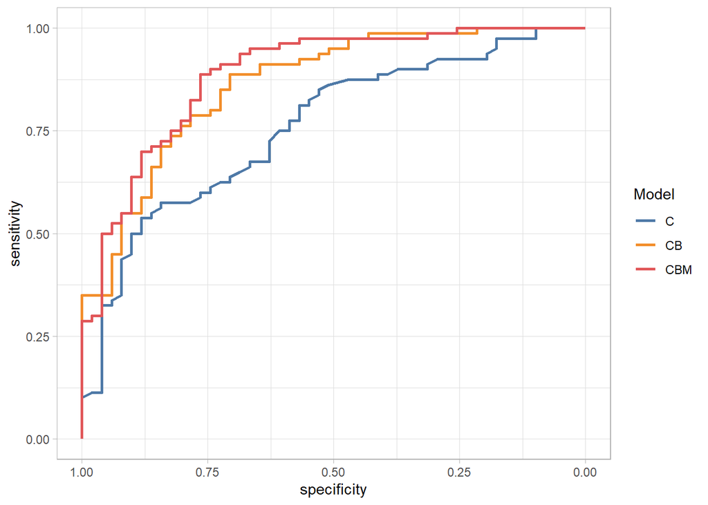

```r
ggroc(data = list(C = rocClinical,
                  CB = rocCB,
                  CBM = rocCBM),
      size = 1,
      aes = c("color")) +
    theme_light() +
    ggthemes::scale_color_tableau(name = "Model")
```

```r
roc.test(rocClinical, rocCB)
```

```
##
##  DeLong's test for two correlated ROC curves
##
## data:  rocClinical and rocCB
## Z = -2.909, p-value = 0.003626
## alternative hypothesis: true difference in AUC is not equal to 0
## sample estimates:
## AUC of roc1 AUC of roc2
##   0.7591912   0.8647059
```

```r
roc.test(rocCB, rocCBM)
```

```
##
##  DeLong's test for two correlated ROC curves
##
## data:  rocCB and rocCBM
## Z = -1.4204, p-value = 0.1555
## alternative hypothesis: true difference in AUC is not equal to 0
## sample estimates:
## AUC of roc1 AUC of roc2
##   0.8647059   0.8872549
```

```r
roc.test(rocClinical, rocCBM)
```

```
##
##  DeLong's test for two correlated ROC curves
##
## data:  rocClinical and rocCBM
## Z = -3.1624, p-value = 0.001565
## alternative hypothesis: true difference in AUC is not equal to 0
## sample estimates:
## AUC of roc1 AUC of roc2
##   0.7591912   0.8872549
```

- ROC curves show the model with clinical risk factors and both tumor staging and liver function assessment has better discrimination than clinical risk factors alone but isn’t substantially improved by AFP

```r
# Accuracy
modelClinical.cut <- optimalCutoff(dataTrain$lives, probTrainClinical)
1 - misClassError(dataTrain$lives, probTrainClinical, threshold = modelClinical.cut)
```

```
## [1] 0.7252
```

```r
modelCB.cut <- optimalCutoff(dataTrain$lives, probTrainCB)
1 - misClassError(dataTrain$lives, probTrainCB, threshold = modelCB.cut)
```

```
## [1] 0.8168
```

```r
modelCBM.cut <- optimalCutoff(dataTrain$lives, probTrainCBM)
1 - misClassError(dataTrain$lives, probTrainCBM, threshold = modelCBM.cut)
```

```
## [1] 0.8397
```

```r
# PPV/NPV
precision(dataTrain$lives, probTrainClinical, threshold = modelClinical.cut)
```

```
## [1] 0.7340426
```

```r
npv(dataTrain$lives, probTrainClinical, threshold = modelClinical.cut)
```

```
## [1] 0.7027027
```

```r
precision(dataTrain$lives, probTrainCB, threshold = modelCB.cut)
```

```
## [1] 0.8255814
```

```r
npv(dataTrain$lives, probTrainCB, threshold = modelCB.cut)
```

```
## [1] 0.8
```

```r
precision(dataTrain$lives, probTrainCBM, threshold = modelCBM.cut)
```

```
## [1] 0.8172043
```

```r
npv(dataTrain$lives, probTrainCBM, threshold = modelCBM.cut)
```

```
## [1] 0.8947368
```

[output not shown]

C: clinical CB: clinical + tumor/liver CBM: clinical + tumor/liver + molecular biomarker

- The model which includes tumor staging and liver function assessments in additional to clinical risk factors improves the model accuracy, concordance, discrimination, and PPV
- This may not be substantially improved with AFP

# Internally validate models on test data

Can these model performances and observed improvements also be seen in the test data?

```r
# Make model predictions on test data
probTestClinical <- predict(modelClinical, type = "response", newdata = dataTest)
probTestCB <- predict(modelCB, type = "response", newdata = dataTest)
probTestCBM <- predict(modelCBM, type = "response", newdata = dataTest)

# Compare ROC curves
rocTestClinical <- roc(dataTest$lives, probTestClinical)
rocTestCB <- roc(dataTest$lives, probTestCB)
rocTestCBM <- roc(dataTest$lives, probTestCBM)

rocTestClinical$auc
```

```
## Area under the curve: 0.6031
```

```r
rocTestCB$auc
```

```
## Area under the curve: 0.5395
```

```r
rocTestCBM$auc
```

```
## Area under the curve: 0.6579
```

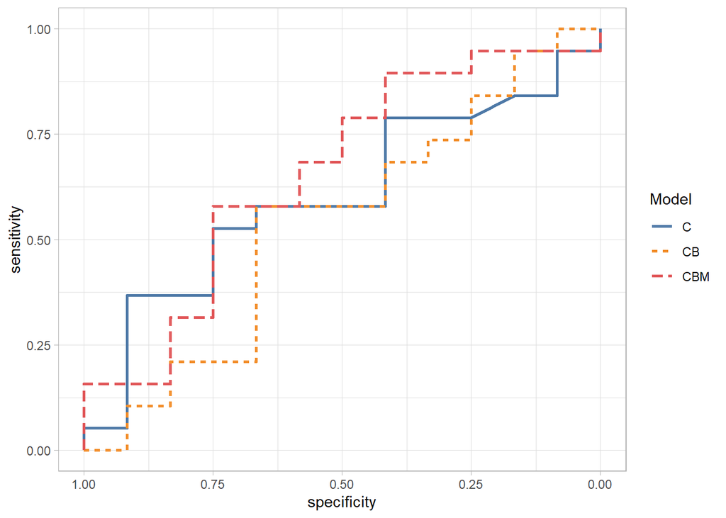

```r
ggroc(data = list(C = rocTestClinical,
                  CB = rocTestCB,
                  CBM = rocTestCBM),
      size = 1,
      aes = c("color", "linetype")) +
    theme_light() +
    scale_linetype(name = "Model") +
    ggthemes::scale_color_tableau(name = "Model")
```

```r
roc.test(rocTestClinical, rocTestCB)
```

```
##
##  DeLong's test for two correlated ROC curves
##
## data:  rocTestClinical and rocTestCB
## Z = 0.46988, p-value = 0.6384
## alternative hypothesis: true difference in AUC is not equal to 0
## sample estimates:
## AUC of roc1 AUC of roc2
##   0.6030702   0.5394737
```

```r
roc.test(rocTestCB, rocTestCBM)
```

```
##
##  DeLong's test for two correlated ROC curves
##
## data:  rocTestCB and rocTestCBM
## Z = -1.8084, p-value = 0.07055
## alternative hypothesis: true difference in AUC is not equal to 0
## sample estimates:
## AUC of roc1 AUC of roc2
##   0.5394737   0.6578947
```

```r
roc.test(rocTestClinical, rocTestCBM)
```

```
##
##  DeLong's test for two correlated ROC curves
##
## data:  rocTestClinical and rocTestCBM
## Z = -0.42095, p-value = 0.6738
## alternative hypothesis: true difference in AUC is not equal to 0
## sample estimates:
## AUC of roc1 AUC of roc2
##   0.6030702   0.6578947
```

```r
# Accuracy
modelClinical.testCut <- optimalCutoff(dataTest$lives, probTestClinical)
1 - misClassError(dataTest$lives, probTestClinical, threshold = modelClinical.cut)
```

```
## [1] 0.6452
```

```r
modelCB.testCut <- optimalCutoff(dataTest$lives, probTestCB)
1 - misClassError(dataTest$lives, probTestCB, threshold = modelCB.testCut)
```

```
## [1] 0.6452
```

```r
modelCBM.testCut <- optimalCutoff(dataTest$lives, probTestCBM)
1 - misClassError(dataTest$lives, probTestCBM, threshold = modelCBM.testCut)
```

```
## [1] 0.7097
```

```r
# Concordance
Concordance(dataTest$lives, probTestClinical)[1]
```

```
## $Concordance
## [1] 0.6008772
```

```r
Concordance(dataTest$lives, probTestCB)[1]
```

```
## $Concordance
## [1] 0.5394737
```

```r
Concordance(dataTest$lives, probTestCBM)[1]
```

```
## $Concordance
## [1] 0.6578947
```

```r
# PPV/NPV
precision(dataTest$lives, probTestClinical, threshold = modelClinical.testCut)
```

```
## [1] 0.6818182
```

```r
npv(dataTest$lives, probTestClinical, threshold = modelClinical.testCut)
```

```
## [1] 0.5555556
```

```r
precision(dataTest$lives, probTestCB, threshold = modelCB.testCut)
```

```
## [1] 0.6333333
```

```r
npv(dataTest$lives, probTestCB, threshold = modelCB.testCut)
```

```
## [1] 1
```

```r
precision(dataTest$lives, probTestCBM, threshold = modelCBM.testCut)
```

```
## [1] 0.7083333
```

```r
npv(dataTest$lives, probTestCBM, threshold = modelCBM.testCut)
```

```
## [1] 0.7142857
```

[output not shown]

C: clinical CB: clinical + tumor/liver CBM: clinical + tumor/liver + molecular biomarker

# K-fold cross validation

```r
ctrl <- trainControl(method = "repeatedcv",
                     number = 10,
                     savePredictions = TRUE)

modelCV.C <- train(lives ~ age + diabetes + hypertension + symptoms + creatinine + leuk,
                   data = data.imp,
                   method = "glm",
                   family = "binomial",
                   trControl = ctrl,
                   tuneLength = 5)
modelCV.C$results
```

```
##   parameter  Accuracy     Kappa AccuracySD   KappaSD
## 1      none 0.6615196 0.2547164  0.1049762 0.2285088
```

```r
predictionsCV.C <- predict(modelCV.C, data.imp)
confusionC <- caret::confusionMatrix(predictionsCV.C, data.imp$lives, positive = "1")
print(confusionC)
```

```
## Confusion Matrix and Statistics
##
##           Reference
## Prediction  0  1
##          0 30 17
##          1 33 82
##
##                Accuracy : 0.6914
##                  95% CI : (0.6141, 0.7615)
##     No Information Rate : 0.6111
##     P-Value [Acc > NIR] : 0.02083
##
##                   Kappa : 0.3192
##
##  Mcnemar's Test P-Value : 0.03389
##
##             Sensitivity : 0.8283
##             Specificity : 0.4762
##          Pos Pred Value : 0.7130
##          Neg Pred Value : 0.6383
##              Prevalence : 0.6111
##          Detection Rate : 0.5062
##    Detection Prevalence : 0.7099
##       Balanced Accuracy : 0.6522
##
##        'Positive' Class : 1
##
```

```r
modelCV.CB <- train(lives ~ age + diabetes + hypertension + symptoms + creatinine + leuk +
                        nodule_dim + hb + ascites + bilirubin_total,
                    data = data.imp,
                    method = "glm",
                    family = "binomial",
                    trControl = ctrl,
                    tuneLength = 5)

modelCV.CB$results
```

```
##   parameter  Accuracy     Kappa AccuracySD   KappaSD
## 1      none 0.7216912 0.3803131 0.09508493 0.2346193
```

```r
predictionsCV.CB <- predict(modelCV.CB, data.imp)
confusionCB <- caret::confusionMatrix(predictionsCV.CB, data.imp$lives, positive = "1")
print(confusionCB)
```

```
## Confusion Matrix and Statistics
##
##           Reference
## Prediction  0  1
##          0 36 11
##          1 27 88
##
##                Accuracy : 0.7654
##                  95% CI : (0.6925, 0.8283)
##     No Information Rate : 0.6111
##     P-Value [Acc > NIR] : 2.274e-05
##
##                   Kappa : 0.4826
##
##  Mcnemar's Test P-Value : 0.01496
##
##             Sensitivity : 0.8889
##             Specificity : 0.5714
##          Pos Pred Value : 0.7652
##          Neg Pred Value : 0.7660
##              Prevalence : 0.6111
##          Detection Rate : 0.5432
##    Detection Prevalence : 0.7099
##       Balanced Accuracy : 0.7302
##
##        'Positive' Class : 1
##
```

```r
modelCV.CBM <- train(lives ~ age + diabetes + hypertension + symptoms + creatinine + leuk +
                         nodule_dim + hb + ascites + bilirubin_total + afp,
                     data = data.imp,
                     method = "glm",
                     family = "binomial",
                     trControl = ctrl,
                     tuneLength = 5)

modelCV.CBM$results
```

```
##   parameter  Accuracy     Kappa AccuracySD   KappaSD
## 1      none 0.7404412 0.4396688  0.1055089 0.2179167
```

```r
predictionsCV.CBM <- predict(modelCV.CBM, data.imp)
confusionCBM <- caret::confusionMatrix(predictionsCV.CBM, data.imp$lives, positive = "1")
print(confusionCBM)
```

```
## Confusion Matrix and Statistics
##
##           Reference
## Prediction  0  1
##          0 36 14
##          1 27 85
##
##                Accuracy : 0.7469
##                  95% CI : (0.6727, 0.8119)
##     No Information Rate : 0.6111
##     P-Value [Acc > NIR] : 0.0001869
##
##                   Kappa : 0.4468
##
##  Mcnemar's Test P-Value : 0.0609187
##
##             Sensitivity : 0.8586
##             Specificity : 0.5714
##          Pos Pred Value : 0.7589
##          Neg Pred Value : 0.7200
##              Prevalence : 0.6111
##          Detection Rate : 0.5247
##    Detection Prevalence : 0.6914
##       Balanced Accuracy : 0.7150
##
##        'Positive' Class : 1
##
```

- 10-fold cross validation of the model consisting of clinical risk factors as well as tumor staging and liver function assessments showed an accuracy of 77%, PPV 77% and NPV 77%

| Model | C | CB | CBM |
| --- | --- | --- | --- |
| Accuracy | 0.69 | 0.77 | 0.75 |
| PPV | 0.71 | 0.77 | 0.76 |
| NPV | 0.64 | 0.77 | 0.72 |
| Sens | 0.83 | 0.89 | 0.86 |
| Spec | 0.48 | 0.57 | 0.57 |

```r
modelCB.imp <- glm(lives ~ age + diabetes + hypertension + symptoms + creatinine +
                       leuk + nodule_dim + hb + ascites + bilirubin_total,
                   data.imp,
                   family = "binomial")
summary(modelCB.imp)
```

```
##
## Call:
## glm(formula = lives ~ age + diabetes + hypertension + symptoms +
##     creatinine + leuk + nodule_dim + hb + ascites + bilirubin_total,
##     family = "binomial", data = data.imp)
##
## Deviance Residuals:
##     Min       1Q   Median       3Q      Max
## -2.1287  -0.7420   0.4251   0.7896   2.0015
##
## Coefficients:
##                   Estimate Std. Error z value Pr(>|z|)
## (Intercept)      1.749e+00  1.707e+00   1.025  0.30551
## age             -2.576e-02  1.713e-02  -1.504  0.13263
## diabetes1       -1.085e+00  4.614e-01  -2.351  0.01870 *
## hypertension1    1.411e+00  5.027e-01   2.808  0.00499 **
## symptoms1       -1.442e+00  4.654e-01  -3.099  0.00194 **
## creatinine      -2.853e-01  2.700e-01  -1.057  0.29064
## leuk            -9.215e-05  6.549e-05  -1.407  0.15938
## nodule_dim      -8.428e-02  3.998e-02  -2.108  0.03504 *
## hb               1.803e-01  9.596e-02   1.879  0.06024 .
## ascites.L       -9.269e-01  4.557e-01  -2.034  0.04196 *
## ascites.Q       -1.265e-01  4.382e-01  -0.289  0.77280
## bilirubin_total -1.367e-01  7.098e-02  -1.926  0.05409 .
## ---
## Signif. codes:  0 '***' 0.001 '**' 0.01 '*' 0.05 '.' 0.1 ' ' 1
##
## (Dispersion parameter for binomial family taken to be 1)
##
##     Null deviance: 216.51  on 161  degrees of freedom
## Residual deviance: 161.49  on 150  degrees of freedom
## AIC: 185.49
##
## Number of Fisher Scoring iterations: 5
```

```r
exp(cbind(coef(modelCB.imp), confint(modelCB.imp)))
```

```
##                                2.5 %      97.5 %
## (Intercept)     5.7508546 0.21095574 178.7623077
## age             0.9745674 0.94105858   1.0069622
## diabetes1       0.3378984 0.13261720   0.8186496
## hypertension1   4.1015378 1.58840335  11.5398091
## symptoms1       0.2363813 0.09063955   0.5700421
## creatinine      0.7518092 0.44913350   1.2920911
## leuk            0.9999079 0.99977770   1.0000369
## nodule_dim      0.9191747 0.84849903   0.9935237
## hb              1.1975904 0.99500773   1.4536243
## ascites.L       0.3957853 0.15577596   0.9494777
## ascites.Q       0.8811541 0.36598372   2.0647454
## bilirubin_total 0.8722252 0.74308060   0.9774685
```

# Nomogram

```r
# Nomogram function
## Create simple Fagan nomograms as ggplot objects
##   Based on Perl web-implementation (https://araw.mede.uic.edu/cgi-bin/testcalc.pl)
##   Authors: AM. Chekroud* & A. Schwartz (* adam dot chekroud at yale . edu)
##   December 2016

nomogrammer <- function(Prevalence,
                        Sens = NULL,
                        Spec = NULL,
                        Plr = NULL,
                        Nlr = NULL,
                        Detail = FALSE,
                        NullLine = FALSE,
                        LabelSize = (14/5),
                        Verbose = FALSE){

    ## Function inputs:
    # Prevalence (prior probability) as a number between 0 and 1
    # Either
    # Sens & Spec
    # model sensitivity and specificity as a number between 0 and 1
    # Or
    # Likelihood ratios
    # Positive and Negative LRs (numeric)

    ## Function options:
    # Detail: If true, will overlay key statistics onto the plot
    # NullLine: If true, will add a line from prior prob through LR = 1
    # LabelSize: Tweak this number to change the label sizes
    # Verbose: Print out relevant metrics in the console

    ## Function returns:
    # ggplot object

    ######################################
    ########## Libraries & Functions #####
    ######################################

    ## Libraries
    require(ggplot2)
    require(scales)

    ## Helper functions
    ##   (defined inside nomogrammer, so remain local only & wont clutter user env)
    odds         <- function(p){
        # Function converts probability into odds
        o <- p/(1-p)
        return(o)
    }

    logodds      <- function(p){
        # Function returns logodds for a probability
        lo <- log10(p/(1-p))
        return(lo)
    }

    logodds_to_p <- function(lo){
        # Function goes from logodds back to a probability
        o <- 10^lo
        p <- o/(1+o)
        return(p)
    }

    p2percent <- function(p){
        # Function turns numeric probability into string percentage
        # e.g. 0.6346111 -> 63.5%
        scales::percent(signif(p, digits = 3))}

    ######################################
    ########## Calculations     ##########
    ######################################

    ## Checking inputs

    ## Prevalence
    # needs to exist
    if(missing(Prevalence)){
        stop("Prevalence is missing")
    }
    # needs to be numeric
    if(!is.numeric(Prevalence)){stop("Prevalence should be numeric")}
    # needs to be a prob not a percent
    if((Prevalence > 1) | (Prevalence <= 0)){stop("Prevalence should be a probability (did you give a %?)")}

    # Did user give sens & spec?
    if(missing(Sens) | missing(Spec)){
        sensspec <- FALSE
    } else{ sensspec <- TRUE}
    # if yes, make sure they are numbers
    if(sensspec == TRUE){
        if(!is.numeric(Sens)){stop("Sensitivity should be numeric")}
        if(!is.numeric(Spec)){stop("Specificity should be numeric")}
        # numbers that are probabilities not percentages
        if((Sens > 1) | (Sens <= 0)){stop("Sensitivity should be a probability (did you give a %?)")}
        if((Spec > 1) | (Spec <= 0)){stop("Specificity should be a probability (did you give a %?)")}
    }

    # Did user give PLR & NLR?
    if(missing(Plr) | missing(Nlr)){
        plrnlr <- FALSE
    } else{plrnlr <- TRUE}
    # if yes, make sure they are numbers
    if(plrnlr == TRUE){
        if(!is.numeric(Plr)){stop("PLR should be numeric")}
        if(!is.numeric(Nlr)){stop("NLR should be numeric")}
        # numbers that vaguely make sense
        if(Plr < 1){stop("PLR shouldn't be less than 1")}
        if(Nlr < 0){stop("NLR shouldn't be below zero")}
        if(Nlr > 1){stop("NLR shouldn't be more than 1")}
    }

    # Did they give a valid sensspec and plrnlr? If yes, ignore the LRs and tell them
    if((sensspec == TRUE) && (plrnlr == TRUE) ){
        warning("You provided sens/spec as well as likelihood ratios-- I ignored the LRs!")
    }

    ## If sens/spec provided, we calculate posterior probabilities & odds using sens & spec
    ##  otherwise, if plr and nlr provided, we calculate posteriors using them
    ##  if neither exist, then return an error
    if(sensspec == TRUE){
        prior_prob  <- Prevalence
        prior_odds  <- odds(prior_prob)
        sensitivity <- Sens
        specificity <- Spec
        PLR <- sensitivity/(1-specificity)
        NLR <- (1-sensitivity)/specificity
        post_odds_pos  <- prior_odds * PLR
        post_odds_neg  <- prior_odds * NLR
        post_prob_pos  <- post_odds_pos/(1+post_odds_pos)
        post_prob_neg  <- post_odds_neg/(1+post_odds_neg)
    } else if(plrnlr == TRUE){
        prior_prob  <- Prevalence
        prior_odds  <- odds(prior_prob)
        PLR <- Plr
        NLR <- Nlr
        sensitivity <- (PLR*(1-NLR))/(PLR-NLR)    ## TODO: check Adam's math!
        specificity <- (1-PLR)/(NLR-PLR)          ## TODO: check Adam's math!
        post_odds_pos  <- prior_odds * PLR
        post_odds_neg  <- prior_odds * NLR
        post_prob_pos  <- post_odds_pos/(1+post_odds_pos)
        post_prob_neg  <- post_odds_neg/(1+post_odds_neg)
    } else{
        stop("Couldn't find sens & spec, or positive & negative likelihood ratios")
    }

    ######################################
    ########## Plotting (prep)  ##########
    ######################################

    ## Set common theme preferences up front
    theme_set(theme_bw() +
                  theme(axis.text.x = element_blank(),
                        axis.ticks.x = element_blank(),
                        axis.title.x = element_blank(),
                        axis.title.y = element_text(angle = 0),
                        axis.title.y.right = element_text(angle = 0),
                        axis.line = element_blank(),
                        panel.grid = element_blank(),
                        legend.position = "none"
                  )
    )

    ## Setting up the points of interest along the y-axes

    # Select probabilities of interest (nb as percentages)
    ticks_prob    <- c(0.1, 0.2, 0.5, 1, 2, 5, 10, 20, 30,
                       40, 50, 60, 70, 80, 90, 95, 99)
    # Convert % to odds
    ticks_odds    <- odds(ticks_prob/100)
    # Convert % to logodds
    ticks_logodds <- logodds(ticks_prob/100)

    # Select the likelihood ratios of interest (for the middle y-axis)
    ticks_lrs     <- sort(c(10^(-3:3), 2*(10^(-3:2)), 5*(10^(-3:2))))
    # Log10 them since plot is in logodds space
    ticks_log_lrs <- log10(ticks_lrs)

    ## Fixing particular x-coordinates
    left     <- 0
    right    <- 1
    middle   <- 0.5
    midright <- 0.75

    ## Lay out the four key plot points
    ##  (the start and finish of the positive and negative lines)

    # Initially these are expressed as probabilities
    df <- data.frame(x=c(left, right, left, right),
                     y=c(prior_prob, post_prob_pos, prior_prob, post_prob_neg),
                     line = c("pos", "pos", "neg", "neg"))

    adj_min      <- range(ticks_logodds)[1]
    adj_max      <- range(ticks_logodds)[2]
    adj_diff     <- adj_max - adj_min
    scale_factor <- abs(adj_min) - adj_diff/2
    #df$lo_y <- ifelse(df$x==left,(10/adj_diff)*logodds(1-df$y)-1,logodds(df$y))

    # Convert probabilities to logodds for plotting
    df$lo_y  <- ifelse(df$x==left,logodds(1-df$y)-scale_factor,logodds(df$y))
    # zero         <- data.frame(x = c(left,right),
    #                            y = c(0,0),
    #                            line = c('pos','pos'),
    #                            lo_y = c(-scale_factor,0))

    rescale   <- range(ticks_logodds) + abs(adj_min) - adj_diff/2
    rescale_x_breaks  <- ticks_logodds + abs(adj_min) - adj_diff/2

    ######################################
    ########## Plot             ##########
    ######################################

    p <- ggplot(df) +
        geom_line(aes(x = x, y = lo_y, color = line), size = 1) +
        geom_vline(xintercept = middle) +
        annotate(geom = "text",
                 x = rep(middle+.075, length(ticks_log_lrs)),
                 y = (ticks_log_lrs-scale_factor)/2,
                 label = ticks_lrs,
                 size = rel(LabelSize)) +
        annotate(geom="point",
                 x = rep(middle, length(ticks_log_lrs)),
                 y = (ticks_log_lrs-scale_factor)/2,
                 size = 1) +
        scale_x_continuous(expand = c(0,0)) +
        scale_y_continuous(expand = c(0,0),
                           limits = rescale,
                           breaks = -rescale_x_breaks,
                           labels = ticks_prob,
                           name = "prior \n prob.",
                           sec.axis = sec_axis(trans = ~.,
                                               name = "posterior \n prob.",
                                               labels = ticks_prob,
                                               breaks = ticks_logodds))

    ## Optional overlay text: prevalence, PLR/NLR, and posterior probabilities
    detailedAnnotation <- paste(
        paste0("prevalence = ", p2percent(prior_prob)),
        paste("PLR =", signif(PLR, 3),", NLR =", signif(NLR, 3)),
        paste("post. pos =", p2percent(post_prob_pos),
              ", neg =", p2percent(post_prob_neg)),
        sep = "\n")

    ## Optional amendments to the plot

    ## Do we add the null line i.e. LR = 1, illustrating an uninformative model
    if(NullLine == TRUE){
        ## If yes, first calculate the start and end points
        uninformative <- data.frame(
            x = c(left,right),
            lo_y = c( (logodds(1-prior_prob) - scale_factor) , logodds(prior_prob))
        )

        p <- p + geom_line(aes(x = x, y = lo_y), data = uninformative,
                           color = "gray",
                           lty = 2,
                           inherit.aes = FALSE)
    }

    ## Do we add the detailed stats to the top right?
    if(Detail == TRUE){
        p <- p + annotate(geom = "text",
                          x = midright,
                          y = 2,
                          label = detailedAnnotation,
                          size = rel(LabelSize))
    }

    if(Verbose == TRUE){
        writeLines(
            text = c(
                paste0("prevalence = ", p2percent(prior_prob)),
                paste("PLR =", signif(PLR, 3)),
                paste("NLR =", signif(NLR, 3)),
                paste("posterior probability (positive) =", p2percent(post_prob_pos)),
                paste("posterior probability (negative) =", p2percent(post_prob_neg)),
                paste("sensitivity =", p2percent(sensitivity)),
                paste("specificity =", p2percent(specificity))
                # sep = "\n"
            )
        )
    }

    return(p)

}
```

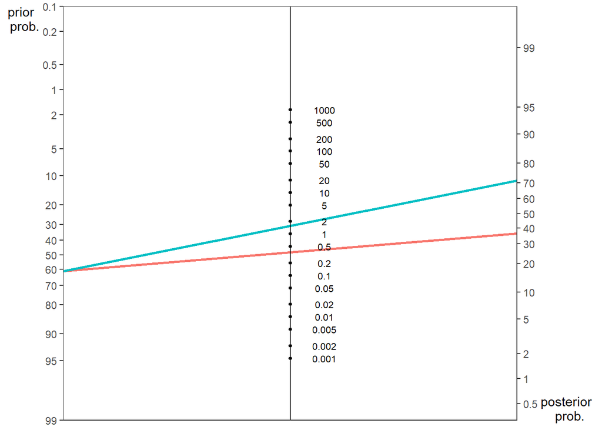

```r
nomogrammer(Prevalence = prop.table(table(data.imp$lives))[2],
            Sens = confusionC$byClass[1], Spec = confusionC$byClass[2])
```

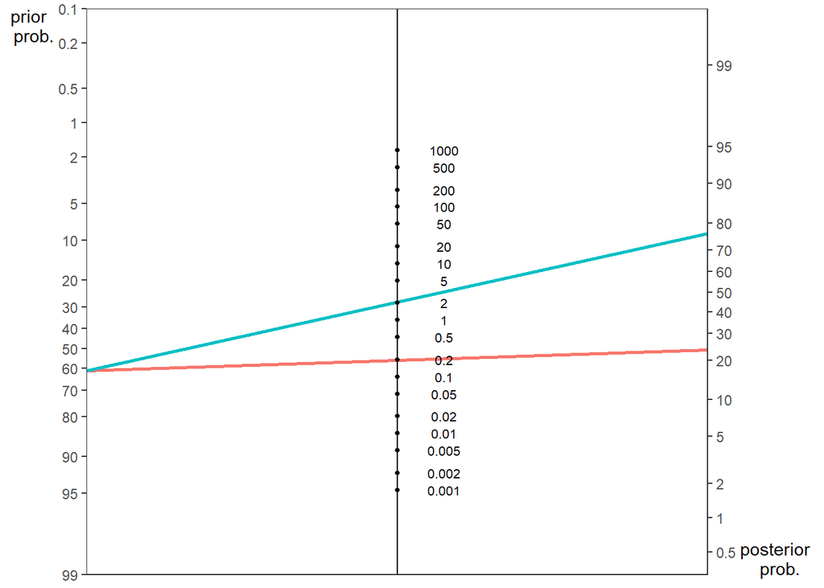

```r
nomogrammer(Prevalence = prop.table(table(data.imp$lives))[2],
            Sens = confusionCB$byClass[1], Spec = confusionCB$byClass[2])
```

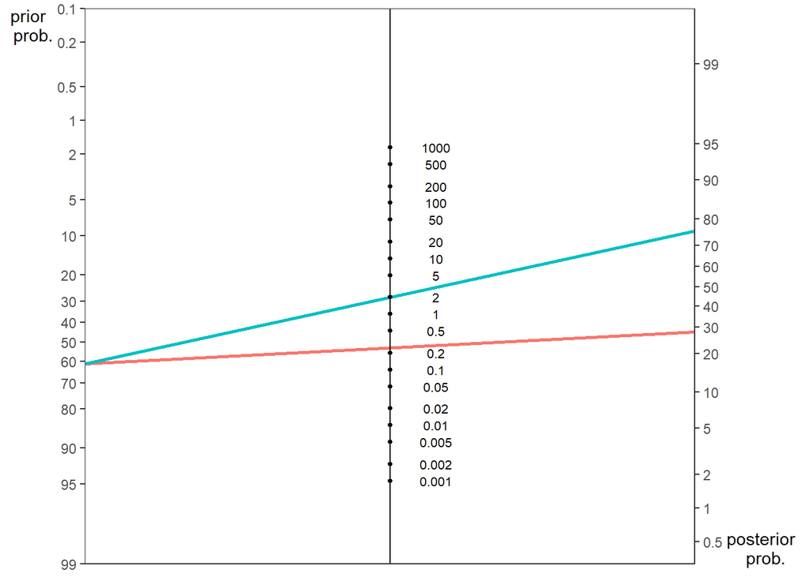

```r
nomogrammer(Prevalence = prop.table(table(data.imp$lives))[2],
            Sens = confusionCBM$byClass[1], Spec = confusionCBM$byClass[2])
```

- As illustrated by the nomogram, given a prevalence of HCC survival of 61.1% (pre-test probability), a positive test result with a model consisting of clinical risk factors only would provide a post-test probability of 71.3%
- A model consisting a clinical risk factors as well as tumor staging and liver function assessments would provide a post-test probability of 76.5% and would not be improved with AFP (75.9%)

# Conclusion

The predictive ability of clinical risk factors to identify survival among patients diagnosed with hepatocellular carcinoma (HCC) was improved with tumor staging and liver function assessments. However, incorporation of molecular biomarkers is not expected to further substantially improve HCC prognostication.